# Seedling growth and survival models and simulation

# Background

**Settings**

```r
# setwd(dir = "../")  # Only run this line when running manually.  Only for knitting.

set.seed(400)
boots = 1000 # 0  #fast: 100, full: 1000
min_grow = -2
max_grow = Inf
bootsize = 50
breakage = T
seedling_variance = T
gap22 = T
min_h = 2
canopy = 1:2 # 1:3  # second option.
canopy_types = c("Closed","Partial", "Open")

# Simulation settings:
n_seedling = 10000    # Fast: 500,  Full: 250,000
timesteps  = 100    # Number of time steps
trials     = 100     # Fast: 5, Full: 100
sample_curves = T

mid_lim <- c(20, 200)

simulate_gompertz = F
simulate_ricker = F

sim_id = Sys.Date()
store_simulation = F


spp_names = spp = c("ACERUB", "BETSP", "PINSTR", "QUERUB", "TSUCAN")

if(identical(canopy, c(1:2))){
  # Two class option.
  canopy1 = c("1", "1,2", "2,1", "2", "2,3")
  canopy2 = c("3,2", "3", "3,4", "4,3", "4", "4,5", "5,4", "5")
  canopy_types = c("Closed", "Open")

  canopy_list <- list(canopy1, canopy2)

}else{
  # Three-class option
  canopy = 1:3
  class1 = c("1", "1,2", "2,1", "2")
  class2 = c("2,3", "3,2", "3", "3,4", "4,3", "4")
  class3 = c("3", "3,4", "4,3", "4",  "4,5", "5,4", "5")

  canopy_list <- list(class1, class2, class3)
}

crown_classes = unlist(canopy_list)
canopy_classes = factor(rep(1:length(canopy_list), unlist(lapply(canopy_list, length))))

spp_max_surv <- c(ACERUB = 0.87, BETSP = 0.91, PINSTR = 0.812, QUERUB = 0.68, TSUCAN = 0.947-0.045)
# spp_max_surv <- c(ACERUB = 0.87, BETSP = 0.91, PINSTR = 0.812, QUERUB = 0.68, TSUCAN = 0.947)

# NLRQ quantile
tau = 0.9

# Display options
pander::panderOptions('table.split.table', Inf)
```

Five species were compared (*ACERUB*, *BETSP*, *PINSTR*, *QUERUB* and *TSUCAN*), across two canopy conditions. For each plot containing seedlings, canopy conditions were assessed during 2022 on a scale of 1 (full canopy) to 5 (full gap). Seedlings in plots which fell on the boundary were given an ordered pair (e.g. 1,2), with the first number indicating the more likely canopy group. Any seedling with a rank of 3,2 or higher was considered to be in open canopy.

For curve fitting we drew 1000 bootstraps of size, bootstrap size 50 from each species by gap class.

Max survival rates were:

| ACERUB | BETSP | PINSTR | QUERUB | TSUCAN |
| --- | --- | --- | --- | --- |
| 0.87 | 0.91 | 0.812 | 0.68 | 0.902 |

The results below are for a simulation wit 10^{4} seedlings per simulation, 100 number of years, and 100 trials. Curve resampling was on, and data logging to disk was off. Breakage in the model was On and the minimum growth breakage threshold was -2 .

## Setup

**Setup**

```r
library(readxl)
library(dplyr)
library(ggplot2)
library(pander)
library(quantreg)
library(nlraa)
library(purrr)
library(reshape2)
library(boot)
library(car)

# Color grid for canopy
canopy_color <- c("#ff504d", "#d6a738", "#76c754")

d <- read.csv("../Data/seedling_measurements.csv")
quad <- read_xlsx("../Data/HF_seedling_2023_quad_data_fix.xlsx")
quad <- quad[,-2]
d.new23 <- read_xlsx(path = "../Data/dat_HF_new22_after_23.xlsx")
d.new23 <- d.new23 %>% rename(Unique_plot_23 = Unique_Plot,
                              Submission.Id_2023 = `Submission Id`,
                              Species_23 = Species,
                              HT_23 = `Height_2023_(cm)`,
                              ST_23 = Status_2023) %>%
  mutate(Unique_Tag = paste(Unique_plot_23, Tag, sep = "."),
         HT_22 = as.numeric(Height_2022),
         ST_22 = "A",
         Status_2022 = "A",
         ST_21 = NA, HT_21 = NA,
         Notes_21 = NA, Quad_Notes_2022 = NA,
         Sumbission.Id_2021 = NA, Crown_Class_22 = NA)

# Repair to unique plot numbers:
quad$Unique_plot_23[which(!is.na(quad$Unique_plot_fix_23))] <- quad$Unique_plot_fix_23[which(!is.na(quad$Unique_plot_fix_23))]

# Functions ---------------------

# Survival:
# Odds, for use in max survival function.
odds <- function(p){
  p / (1 - p)
}

# Convert average species survival, light class mean survival, and species max survival to light class max survival.
max_surv <- function(species_max, species_mean, species_canopy_mean){
  OR <- odds(species_max) / odds(species_mean)
  sp_can_max_odds <- odds(species_canopy_mean) * OR
  sp_can_max_p <- sp_can_max_odds / (1 + sp_can_max_odds)
  return(sp_can_max_p)
}

# Bootstrapping -----------------
boot_stat <- function(new_dat, new_start, ...){
  logis_i <- try(nls(y ~ SSlogis(x, a, b, c),
                     data = new_dat, start = start_li))

  if(is.character(logis_i)){
    return(c(a = NA, b = NA, c = NA))
  }else{
    if(is.list(logis_i)){
      # GLM
      return(coef(logis_i))
    }else{
      # Optim
      return(logis_i$par)
    }

  }

}

boot_ricker <- function(new_dat, new_start, ...){
  rick_i <- try(nls(y ~ SSricker(x, a, b),
                    data = new_dat, start = start_ri, ...))

  if(is.character(rick_i)){
    return(c(a = NA, b = NA))
  }else{
    return(coef(rick_i))
  }
}

boot_gompertz <- function(new_dat, new_start, ...){
  gomp_i <- try(nls(y ~ SSgompertz(x, a, b, c),
                    data = new_dat, start = start_gi, ...))

  if(is.character(gomp_i)){
    return(c(a = NA, b = NA, c = NA))
  }else{
    return(coef(gomp_i))
  }
}

boot_rand <- function(new_dat, mle = NA){
  return(sample_n(new_dat, size = bootsize, replace = T))
}

# Logistic ----------------------

logis <- function(x, params){
  params[[1]] / (1 + exp((params[[2]]- x) / params[[3]]))
}

fit_logis <- function(params, x, y){
  est_y <- logis(x, params)
  loss <- sum((y - est_y)^2, na.rm = T)
  return(loss)
}

# Medoids
find_medoid <- function(mat){
  dmat <- dist(mat)
  mdmat <- as.matrix(dmat)
  sum_dists <- apply(mdmat, MARGIN = 1, FUN = sum, na.rm = T)
  nonzero_dist <- which(sum_dists > 0)
  min_index <- which(sum_dists[nonzero_dist] == min(sum_dists[nonzero_dist]))[[1]]
  most_central <- mat[as.numeric(names((sum_dists[nonzero_dist])[min_index])), ]
  return(most_central)
}

# Plotting ----------------------

#' A single plot show the fitted curves from bootstrapped parameters, overlaid on data.
plot_logis <- function(dat, boot, alph = 22, point_alpha = 0.25, add = F, col = "#77777733", ...){

  fit_par <- apply(boot, MARGIN = 2, FUN = median, na.rm = T)
  names(fit_par) <- c("a", "b", "c")

  if (add == F){
    plot(dat, xlab = "Height", ylab = "Growth", pch = 20,
         col = alpha(col, alpha = point_alpha), ...)

  } else{
    points(dat, pch = 20, col = alpha(col, alpha = point_alpha), ...)
  }

  fit_curves <- which(complete.cases(boot))
  for(fi in fit_curves){
    lines(x = xgrid, y = SSlogis(input = xgrid,
                                 Asym = boot[fi, 1],
                                 xmid = boot[fi, 2],
                                 scal = boot[fi, 3]),
          lwd = 2, col = col, ...)
  }

  lines(x = xgrid,
        y = SSlogis(input = xgrid,
                    Asym = fit_par[["a"]],
                    fit_par[["b"]],
                    scal = fit_par[["c"]]),
        col = alpha(col, alpha = 1),
        lwd = 2)

}


#'  Plot showing curve fit by species and light class overlaid on data
#'
plot_spp <- function(si, line_alpha = 0.05, point_alpha = 0.05, max_grow = 40){
  ci = 1

  if(gap22){

    A21_i  <-
      subset(A, A$Species_23 == spp[si] & A$Crown_Class_22 %in%
               canopy_list[[ci]]) %>%
      filter(grow21 > min_grow, HT_21 >= min_h)

    A22_i  <-
      subset(A, A$Species_23 == spp[si] & A$Crown_Class_22 %in%
               canopy_list[[ci]]) %>%
      filter(grow > min_grow, HT_22 >= min_h)

  }else{

    A21_i  <-
      subset(A, A$Species_23 == spp[si] & A$Crown_Class_22 %in%
               canopy_list[[ci]]) %>%
      filter(grow21 > min_grow, HT_21 >= min_h)

    A22_i  <-
      subset(A, A$Species_23 == spp[si] & A$Crown_Class_22 %in%
               canopy_list[[ci]]) %>%
      filter(grow > min_grow, HT_22 >= min_h)
  }


  dat_i = data.frame(x = c(A22_i$HT_22, A21_i$HT_21),
                     y = c(A22_i$grow,  A21_i$grow21))

  plot_logis(dat = dat_i, boot = dat[[si]][[ci]]$logistic.boot$t,
             main = paste(spp[si]), add = F,
             ylim = c(min_grow, max_grow),
             col = alpha(canopy_color[ci], alpha = line_alpha),
             point_alpha = point_alpha)

  for (ci in 2:length(canopy)){
    A21_i  <-
      subset(A, A$Species_23 == spp[si] & A$Crown_Class_22 %in%
               canopy_list[[ci]]) %>%
      filter(grow21 > min_grow, HT_22 >= min_h)

    A22_i  <-
      subset(A, A$Species_23 == spp[si] & A$Crown_Class_23 %in%
               canopy_list[[ci]]) %>%
      filter(grow > min_grow, HT_22 >= min_h)

    dat_i = data.frame(x = c(A22_i$HT_22, A21_i$HT_21),
                       y = c(A22_i$grow, A21_i$grow21))

    plot_logis(dat = dat_i,
               boot = dat[[si]][[ci]]$logistic.boot$t, add = T,
               col = alpha(canopy_color[ci], alpha = line_alpha),
               point_alpha = point_alpha)

  }

}

plot_par <- function(par_dat, probs = c(0.05, 0.95), par_names){
  par_initial = par("mfrow")
  npar <- ncol(par_dat)
  par(mfrow = c(1, npar))
  for(par_i in 1:npar){
    par_dat_i <- par_dat[ , par_i]
    dat_quant <- quantile(par_dat_i, probs = probs, na.rm = T)
    hist(par_dat[
      (par_dat_i > dat_quant[1]) & (par_dat_i < dat_quant[2])],
         freq = T, main = par_names[par_i], xlab = "")
  }
  par(mfrow = par_initial)
}
```

**Data cleaning**

```r
# Omitted reference to Height_2022.

# Which of these would be flagged on their own?
d[which(d$Unique_Tag == "340694_120_6.50"), "HT_22"] <- 25  # 25 not 2.5

d[which(d$Unique_Tag == "120313_120_2.76"), "HT_21"] <- NA  # Reading error.
d[which(d$Unique_Tag == "330876_0_6.38"), c("HT_21")]  <- 11   # 8, 14, 14 -> 11, 14, 14 Based on note
d[which(d$Unique_Tag == "330876_0_6.59"), c("HT_21")]  <- 12   # 7, 15, NA -> 12, 15, NA Based on note
d[which(d$Unique_Tag == "120313_0_2.85"), c("HT_21")]  <- 10   # 7, 12, 10 -> 10, 12, 10 Based on note


# More Querub fixes from "delta_growth.R
d[which(d$Unique_Tag == "022156_120_2.68"), "HT_22"]       <- 9       # 19, 90, 11 -> 19, 9, 11
d[which(d$Unique_Tag == "351355_120_2.38"), c("HT_22")]  <- 21.5      # 20, 2.5, 22.5 -> 20, 21.5, 22.5
d[which(d$Unique_Tag == "171421_240_6.64"), c("HT_22")]  <- NA        # 14, 30.5, 15.5 ... What is the middle point? No break note.
d[which(d$Unique_Tag == "120313_0_2.64"), c("HT_21")]  <- 9      # 89,  12, 10  -> 9,  12, 10  Querub Based on note
d[which(d$Unique_Tag == "061110_120_2.26"), c("HT_21")]  <- 10   # 100, 13, 19  -> 10, 13, 19 Acerub Based on note
d[which(d$Unique_Tag == "151940_240_2.7"), c("HT_21")]   <- 15   # 18,  17, 16  -> 15, 17, 16 Querub Based on note
d[which(d$Unique_Tag == "120313_0_2.85"), c("HT_21")]    <- 10   # 7,   12, 10  -> 10, 12, 10 Querub Based on note

# Other species
d[which(d$Unique_Tag == "061285_120_6.89"), c("HT_21")]  <- 27   # 107, 30, 31  -> 27, 30, 31   Tsucan Based on note
d[which(d$Unique_Tag == "070230_120_6.74"), c("HT_21")]  <- 8    # 80, 10, 10.5 -> 8, 10, 10.5  Acerub Based on note
d[which(d$Unique_Tag == "070864_120_6.NA"), c("HT_21")]  <- 8    # 80, 8.5, 11  -> 80, 8.5, 11  Acerub Based on note
d[which(d$Unique_Tag == "070864_0_6.48"), c("HT_21")]    <- 38   # 78, 40, 42   -> 38, 40, 42   Tsucan Based on note
d[which(d$Unique_Tag == "040979_240_2.86"), c("HT_22")]   <- 5.5   # 4, 55, 6   -> 4, 5.5, 6    Acerub note
d[which(d$Unique_Tag == "061285_0_6.8"), c("HT_22")]   <- NA       # Betsp: 142, 17, 141 -> 142, NA, 141 (No notes)

d[which(d$Unique_Tag == "171421_240_2.51"), c("HT_21", "HT_22")]   <- NA  # 78, 74, NA   Pinstr high leverage point

# Edits from 4/20/24
d[which(d$Unique_Tag == "261713_240_6.61"), c("HT_21")]   <- 152   # 125, 157, NA -> 152, 157, NA
d[which(d$Unique_Tag == "070864_0_6.95"),   c("HT_21")]   <- 85    # 65, 96, 91 -> 65, 85, 91
d[which(d$Unique_Tag == "070864_0_2.17"),   c("HT_22")]   <- 24    #  4, 28, 41 -> 24, 28, 41
d[which(d$Unique_Tag == "080956_240_2.20"),   c("HT_22")]   <- 181 #  170, 191, 178 -> 170, 181, 178
d[which(d$Unique_Tag == "311758_120_6.3"),   c("HT_23")]    <- 27  #  10, 24, 2.7 -> 10, 24, 27
d[which(d$Unique_Tag == "070864_0_6.11"),   c("HT_22")]     <- 37  #  36, 47, 37 -> 36, 37, 37
d[which(d$Unique_Tag == "101052_120_2.74"),   c("HT_21")]   <- 4   #  2, 5.5, 7  -> 4, 5.5, 7

d[which(d$Unique_Tag == "040979_120_2.20"),   c("HT_22")]   <- 16  #  6, 6, 25 -> 6, 16, 25
d[which(d$Unique_Tag == "080956_120_6.71"),   c("HT_21")]   <- 4   #  6, 4.5, 5 -> 4, 4.5, 5
d[which(d$Unique_Tag == "191191_0_6.7"),   c("HT_21")]      <- 8   #  6, 12, NA -> 8, 12, NA
d[which(d$Unique_Tag == "091455_0_2.155"),   c("HT_21")]    <- NA  #  5, 11, 11 -> NA, 11, 11
d[which(d$Unique_Tag == "061110_240_2.6"),   c("HT_21")]    <- 29  #  39, 31, 34.5 -> 29, 31, 34.5
d[which(d$Unique_Tag == "091572_0_2.58"),   c("HT_21")]     <- 128 #  148, 135, 162 -> 128, 135, 162
d[which(d$Unique_Tag == "171421_0_2.96"),   c("HT_21")]     <- 16  #  11, 20, 17.5 -> 16, 20, 17.5
d[which(d$Unique_Tag == "061110_120_2.45"),   c("HT_21")]   <- 16  #  18, 18, 18 -> 16, 18, 18
d[which(d$Unique_Tag == "330876_120_2.90"),   c("HT_21")]   <- 19  #  11, 21, 23 -> 19, 21, 23
d[which(d$Unique_Tag == "061110_120_2.40"),   c("HT_21")]   <- 28  #  38, 30, 32 -> 28, 30, 32
d[which(d$Unique_Tag == "040979_120_2.54"),   c("HT_21")]   <- 34  #  44, 44, 35 -> 34, 44, 35
d[which(d$Unique_Tag == "022156_240_2.10"),   c("HT_21")]   <- 5   #   7,  6, NA ->  5,  6, NA
d[which(d$Unique_Tag == "140286_0_2.67"),     c("HT_21")]   <- 6.5 #  2, NA, NA  -> 6.5, NA, NA
d[which(d$Unique_Tag == "061110_240_2.20"),   c("HT_21")]   <- 7   #  12, 8.5, 12 ->  7, 8.5, 12
d[which(d$Unique_Tag == "291578_120_6.12"),   c("HT_21")]   <- 8   #   4, 11, 12.5 -> 8, 11, 12.5
d[which(d$Unique_Tag == "040979_120_2.31"),   c("HT_21")]   <- 8   #   5, 11, 12   -> 8, 11, 12
d[which(d$Unique_Tag == "260982_0_2.61"),   c("HT_21")]    <- 135  # 145, 148, 150.5 -> 135, 148, 150.5
d[which(d$Unique_Tag == "260982_0_2.38"),   c("HT_21")]    <- 180  # 220, 209, 211.5 -> 180, 209, 211.5
d[which(d$Unique_Tag == "091455_240_6.3"),   c("HT_21")]   <- 15   #  10, 18, 25 -> 15, 18, 25
d[which(d$Unique_Tag == "072007_120_2.31"),   c("HT_21")]   <- 6   #   9,  9, 10 ->  6,  9, 10


d[which(d$Unique_Tag == "201215_240_6.48"),   c("HT_21")]   <- 5.5   # 30, 8.5, 10  ->  5.5, 8.5, 10
d[which(d$Unique_Tag == "072007_240_2.48"),   c("HT_21")]   <- 10    #  7, 12, 12.5 ->  10, 12, 12.5
d[which(d$Unique_Tag == "061110_120_2.52"),   c("HT_21")]   <- 12    # 22, 13.5, 13 ->  12, 13.5 13
d[which(d$Unique_Tag == "050958_0_6.92"),     c("HT_21")]   <- 6     #  3,  7.5, NA ->   6, 7.5, NA
d[which(d$Unique_Tag == "031421_120_6.76"),   c("HT_21")]   <- 8     #  5,  10, 11.5 ->  8, 10, 11.5
d[which(d$Unique_Tag == "061285_0_2.13"),     c("HT_21")]   <- 54    # 64, 64, 67   ->  54, 64, 67
d[which(d$Unique_Tag == "120313_0_2.9"),      c("HT_21")]   <- 5     #  3, 6.5, 8.5 ->   5, 6.5, 8.5
d[which(d$Unique_Tag == "120313_0_2.91"),     c("HT_21")]   <- 8     #  5,  10,  9  ->   8, 10, 9
d[which(d$Unique_Tag == "120313_0_6.95"),     c("HT_21")]   <- 6     #  4,  8,  NA  ->   6, 8, NA
d[which(d$Unique_Tag == "061285_0_6.49"),     c("HT_21")]   <- 88    # 98, 95, 95.5 ->  88, 95, 95.5

d[which(d$Unique_Tag == "070864_120_2.88"),   c("HT_23")]   <- 8.5   # 7, 8, 88     ->  7, 8, NA (tag = 88)
```

**Canopy class and final dataset preparation**

```r
quad$canopy_22 <- quad$Crown_Class_22
quad$canopy_23 <- quad$Crown_Class_23

colnames(quad)[6] <- "Submission.Id_2023"
quad_sub <- subset(quad, select = c("Submission.Id_2023","Crown_Class_22", "Crown_Class_23", "Unique_plot_23"))
seedlings <- merge(d,  quad_sub, by = "Submission.Id_2023", all = F)

# Importing new data for 2022-2023
d.new23$canopy_22 <- NA
d.new23$canopy_23 <- d.new23$Crown_Class_23
seed.new23 <- d.new23 %>% select(names(seedlings))
seedlings.upd <- rbind(seedlings, seed.new23)

# Cleaning
seedlings.upd[which(seedlings.upd$Unique_Tag == "051094_0_2.48"), "Crown_Class_23"] <- "4"
seedlings.upd[which(seedlings.upd$Unique_Tag == "080956_0_2.77"), "Crown_Class_23"] <- "3"
seedlings.upd[which(seedlings.upd$Unique_Tag == "061285_240_2.35"), "Crown_Class_22"] <- "4"
seedlings.upd[which(seedlings.upd$Unique_Tag == "080956_120_6.49"), c("Crown_Class_22", "Crown_Class_23")] <- "4"

save(list = c("seedlings.upd"), file = "../Data/Output/seedlings.upd.Rdata")
write.csv(x = seedlings.upd, file = "../Data/Output/seedlings.upd.csv")

# # CFS designates "can't find seedling".
# Select seedlings alive in 2022 (for growth modeling)
A     <- subset(seedlings.upd, seedlings.upd$ST_22 == "A")

A$grow <- A$HT_23 - A$HT_22
A$grow21 <- A$HT_22 - A$HT_21
```

# Parameter Estimation

## Survival

**Survival modeling**

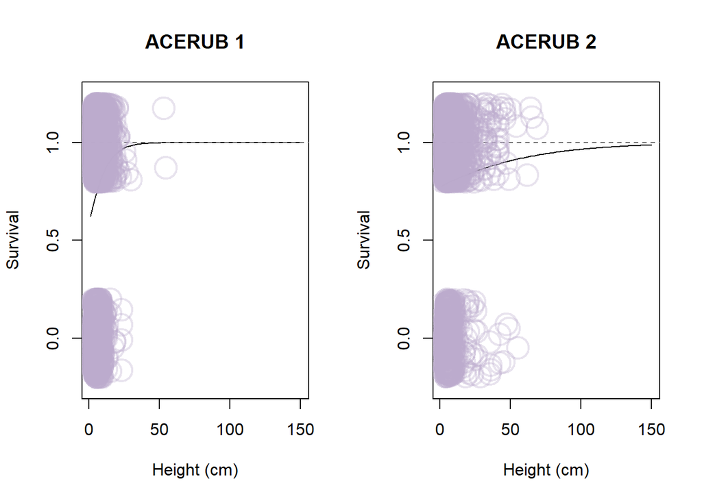

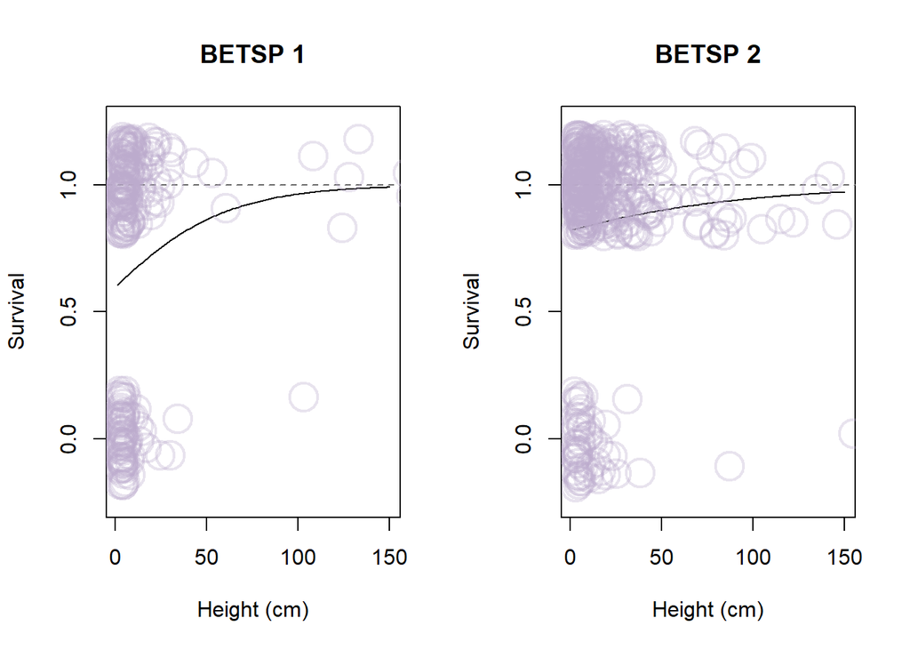

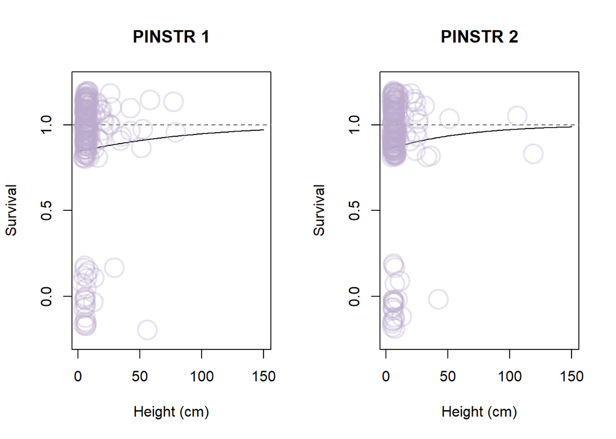

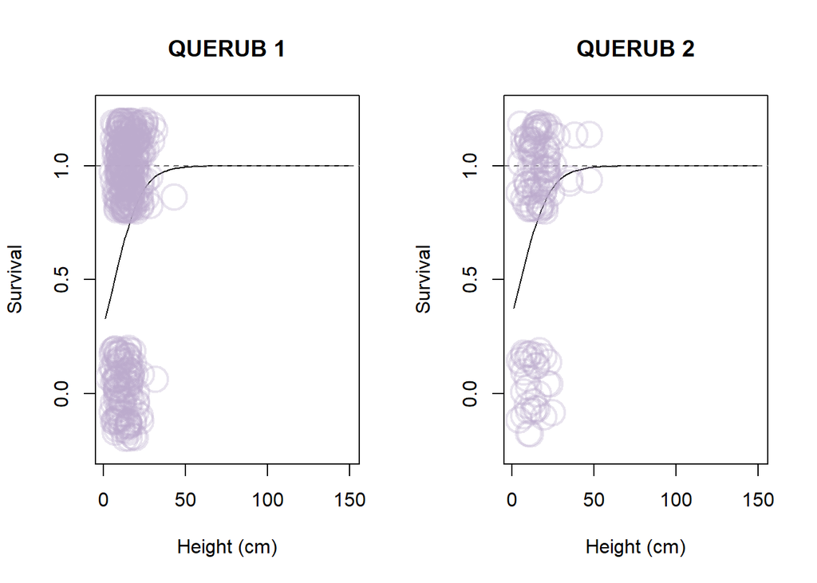

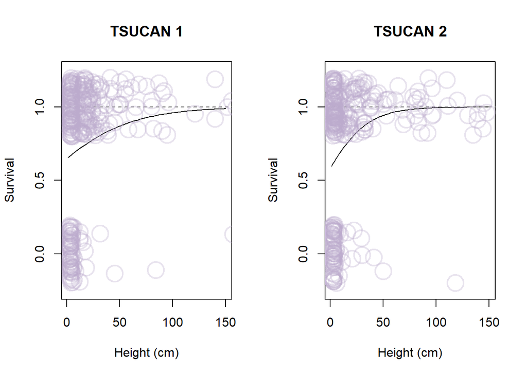

```r
A_21 <- subset(seedlings.upd, seedlings.upd$ST_21 == "A")
A_22 <- subset(seedlings.upd, seedlings.upd$ST_22 == "A")

A_21$plot <- sub("\\..*", "", A_21$Unique_Tag)
A_22$plot <- sub("\\..*", "", A_22$Unique_Tag)

dat_1 <- data.frame(
  Unique_tag = A_21$Unique_Tag,
  Plot = A_21$plot,
  Tree = A_21$Tree,
  Transect = A_21$Transect,
  Distance = A_21$Distance,
  sp = A_21$Species_23,
  X = A_21$X,
  Y = A_21$Y,
  stat1 = A_21$ST_21,
  stat2 = A_21$ST_22,
  HT1 = A_21$HT_21,
  HT2 = A_21$HT_22,
  census = rep(1, nrow(A_21)),
  canopy1 = A_21$Crown_Class_22
)

dat_2 <- data.frame(
  Unique_tag = A_22$Unique_Tag,
  Plot = A_22$plot,
  Tree = A_22$Tree,
  Transect = A_22$Transect,
  Distance = A_22$Distance,
  sp = A_22$Species_23,
  X = A_22$X,
  Y = A_22$Y,
  stat1 = A_22$Status_2022,
  stat2 = A_22$ST_23,
  HT1 = A_22$HT_22,
  HT2 = A_22$HT_23,
  census = rep(1, nrow(A_22)),
  canopy1 = A_22$Crown_Class_23
)

# Override with canopy with individual years using canopy 2022?
if(gap22){
  dat_1$canopy1 = A_21$Crown_Class_22
  dat_2$canopy1 = A_22$Crown_Class_22
}


dat <- rbind(dat_1, dat_2)

# Treat all states other than alive as "dead", including "missing" or "can't find seedling"
dat$surv <- ifelse(dat$stat2 =="A", yes = 1, no = 0)

# For plotting logistic curves
xgrid <- seq(from = 1, to = 150, length.out = 100)

# Empty lists to store models and results
model_list <- list()
result_list <- list()

# Empty dataframe to store the final results
result_table <- data.frame()
result_table_species <- data.frame()
result_table_species_canopy <- data.frame()

# Loop through each species
i = 1
j = 1

for (i in seq_along(spp)) {

  par(mfrow = c(1,2))
  species <- spp[i]

  # By species survival model, without light class.
  dat_species <- dat |> filter(sp == species, stat1 == "A")

  # Create a binary outcome variable based on the canopy
  dat_species$surv <- as.numeric(dat_species$stat2 == "A")

  # Fit logistic regression model
  surv_sp_intercept <- glm(surv ~ 1, data = dat_species, family = "binomial")

  result_table_species <-
    bind_rows(result_table_species,
              mutate(broom::tidy(surv_sp_intercept), spp = i, n = nrow(dat_species)))


  # Loop through each set of canopies
  for (j in seq_along(canopy_list)) {

    # Subset data for the current species and Canopy
    dat_species_canopy <- dat |> filter((sp == species) & (canopy1 %in% canopy_list[[j]]), stat1 == "A")
    # 171421_240_2.51
    # Create a binary outcome variable based on the canopy
    dat_species_canopy$surv <- as.numeric(dat_species_canopy$stat2 == "A")

    # Intercept model for species x canopy combinations:
    surv_sp_canopy_intercept <- glm(surv ~ 1, data = dat_species_canopy, family = "binomial")
    result_table_species_canopy <- bind_rows(
      result_table_species_canopy,
      mutate(broom::tidy(surv_sp_canopy_intercept),
             spp = i, canopy = j, n = nrow(dat_species_canopy)))


    # Fit logistic regression model
    surv_mod <- glm(surv ~ HT1, data = dat_species_canopy, family = "binomial")

    b0_i <- coef(surv_mod)[[1]]
    b1_i <- coef(surv_mod)[[2]]

    logodds <- b0_i + xgrid * b1_i
    prob <- exp(logodds) / (1 + exp(logodds))

    plot(x = xgrid, y = prob, type = "l", ylim = c(-0.25, 1.25),
         main = paste(spp[i], j), xlab = "Height (cm)", ylab = "Survival")
    abline(h = 1, lty = "dashed", col = "grey40")
    points(x = dat_species_canopy$HT1,
           y = jitter(dat_species_canopy$surv), col = "#BBAACC55", cex = 3, lwd = 2)


    # Store the model in the list
    model_list[[paste(i, "_canopy", j, sep = "")]] <- surv_mod

    # Extract and store model results
    result_list[[paste(i, "_canopy", j, sep = "")]] <- broom::tidy(surv_mod)

    # Add the spp and canopy columns to the results dataframe
    result_table <- bind_rows(result_table,
                              mutate(broom::tidy(surv_mod), spp = i, canopy = j, n = nrow(dat_species_canopy)))
  }
}
```

**Survival modeling**

```r
par(mfrow = c(1, 1))
result_table_species$surv <- plogis(result_table_species$estimate)
result_table_species_canopy$surv <- plogis(result_table_species_canopy$estimate)
```

**Maximum survival rates**

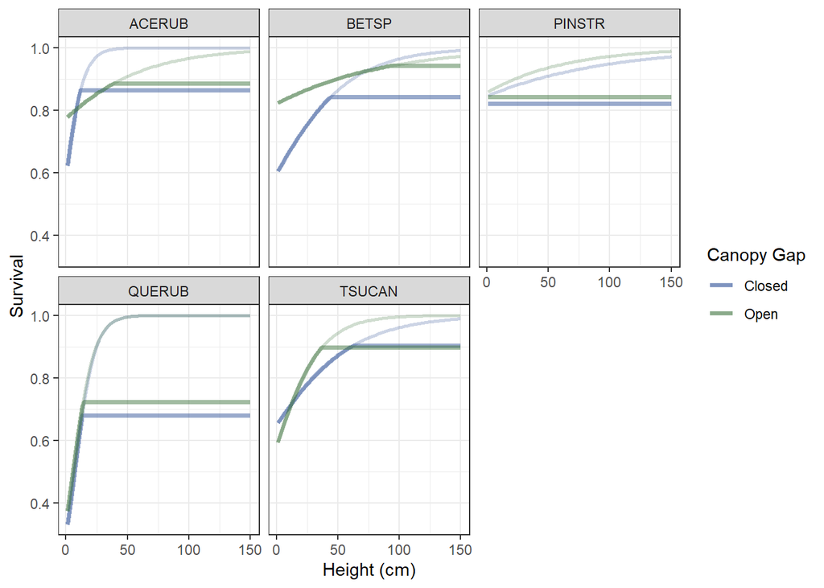

```r
# Function for assigning heights by tree type
get_ht <- function(sp_n){
  ht <- rep(NA, length(sp_n))
  ht[sp_n == 1] <- runif(sum(sp_n == 1), 3.5, 5.5)
  ht[sp_n == 2] <- rnorm(sum(sp_n == 2), 2.7, .56)
  ht[sp_n == 3] <- rnorm(sum(sp_n == 3), 5.375, 0.8717043)
  ht[sp_n == 4] <- runif(sum(sp_n == 4), 10, 13)
  ht[sp_n == 5] <- rnorm(sum(sp_n == 5), 3.5,  0.5431717)

  return(ht)
}


dat_surv <- result_table

# Survival parameters
surv_props <- data.frame(result_table_species_canopy,
                         surv_sp = rep(result_table_species$surv, each = length(canopy)),
                         surv_sp_max = rep(spp_max_surv, each = length(canopy)))

surv_props$surv_sp_canopy_max <-
  max_surv(species_max = surv_props["surv_sp_max"],
           species_mean = surv_props["surv_sp"],
           species_canopy_mean = surv_props["surv"])[[1]]

write.csv(surv_props,"../Data/Output/max_survival_params.csv", row.names = F)




plot_dat <- data.frame()
for (i in seq_along(spp)) {
  species <- spp[i]

  # Loop through each set of canopies
  for (j in seq_along(canopy_list)) {

    dat_species <- subset(dat, (sp == species) & (canopy1 %in% canopy_list[[j]]))
    which_surv <- which((surv_props$spp == i) & (surv_props$canopy == j))
    # Create a binary outcome variable based on the canopy
    dat_species$surv <- as.numeric(dat_species$stat2 == "A")

    # Fit logistic regression model
    surv_mod <- glm(surv ~ HT1, data = dat_species, family = "binomial")
    b0_i <- coef(surv_mod)[[1]]
    b1_i <- coef(surv_mod)[[2]]

    logodds <- b0_i + xgrid * b1_i
    prob <- exp(logodds) / (1 + exp(logodds))
    prob_dat <- data.frame(
      ht = xgrid,
      pr = prob,
      pr_max = pmin(prob, surv_props$surv_sp_canopy_max[which_surv]),
      species = i, canopy = j)
    plot_dat <- rbind(plot_dat, prob_dat)
  }
}


# Show max surv

open_closed <- ggplot(plot_dat |> mutate(canopy = factor(canopy, labels = canopy_types)),
                      mapping = aes(x = ht, y = pr)) +
  geom_line(mapping = aes(color = canopy),
            lwd = 1, alpha = 0.25) +
  geom_line(mapping = aes(x = ht, y = pr_max,
                          color = canopy),
            lwd = 1.25, alpha = 0.5) +
  scale_color_manual(name = "Canopy Gap", values = c("#335599", "#447744", "#883388")) +
  # scale_linetype_manual(values = c(3,2,1), name = "Canopy Gap") +
  theme_bw() + labs(x = "Height (cm)", y = "Survival") +
  facet_wrap(~spp[species])
open_closed
```

**Maximum survival rates**

```r
# Figure: Survival by canopy and canopy gap class (open/closed)
ggsave(filename = "../Images/survival_canopy.png", plot = open_closed,
       height = 6, width = 8)


write.csv(x = result_table |> arrange(spp, canopy), file = paste0("../Data/Output/result_table_surv", length(canopy), ".csv"))
```

**Overall survival**

```r
pander::pander(surv_props |>  mutate(spp = spp_names[spp]), caption = "Species Overall Survival Proportions")
```

Species Overall Survival Proportions

| term | estimate | std.error | statistic | p.value | spp | canopy | n | surv | surv_sp | surv_sp_max | surv_sp_canopy_max |
| --- | --- | --- | --- | --- | --- | --- | --- | --- | --- | --- | --- |
| (Intercept) | 1.193 | 0.04281 | 27.86 | 7.5e-171 | ACERUB | 1 | 3055 | 0.7673 | 0.7775 | 0.87 | 0.8633 |
| (Intercept) | 1.4 | 0.0515 | 27.18 | 9.854e-163 | ACERUB | 2 | 2376 | 0.8022 | 0.7775 | 0.87 | 0.8859 |
| (Intercept) | 0.6931 | 0.1424 | 4.869 | 1.124e-06 | BETSP | 1 | 222 | 0.6667 | 0.7915 | 0.91 | 0.842 |
| (Intercept) | 1.806 | 0.1417 | 12.75 | 3.244e-37 | BETSP | 2 | 411 | 0.8589 | 0.7915 | 0.91 | 0.9419 |
| (Intercept) | 1.785 | 0.2119 | 8.424 | 3.631e-17 | PINSTR | 1 | 181 | 0.8564 | 0.8494 | 0.812 | 0.8203 |
| (Intercept) | 1.946 | 0.2182 | 8.917 | 4.777e-19 | PINSTR | 2 | 192 | 0.875 | 0.8494 | 0.812 | 0.8428 |
| (Intercept) | 0.8388 | 0.1102 | 7.614 | 2.667e-14 | QUERUB | 1 | 391 | 0.6982 | 0.6978 | 0.68 | 0.6804 |
| (Intercept) | 1.047 | 0.2023 | 5.173 | 2.298e-07 | QUERUB | 2 | 127 | 0.7402 | 0.6978 | 0.68 | 0.7239 |
| (Intercept) | 1.016 | 0.1305 | 7.788 | 6.823e-15 | TSUCAN | 1 | 301 | 0.7342 | 0.7307 | 0.902 | 0.9036 |
| (Intercept) | 0.9518 | 0.1292 | 7.365 | 1.766e-13 | TSUCAN | 2 | 298 | 0.7215 | 0.7307 | 0.902 | 0.8978 |

**Survival by light class**

```r
pander::pander(result_table |> mutate(spp = spp_names[spp]), caption = "Survival Proportions")
```

Survival Proportions

| term | estimate | std.error | statistic | p.value | spp | canopy | n |
| --- | --- | --- | --- | --- | --- | --- | --- |
| (Intercept) | 0.3786 | 0.1328 | 2.85 | 0.004373 | ACERUB | 1 | 3055 |
| HT1 | 0.1278 | 0.02039 | 6.266 | 3.699e-10 | ACERUB | 1 | 3055 |
| (Intercept) | 1.233 | 0.08846 | 13.93 | 3.894e-44 | ACERUB | 2 | 2376 |
| HT1 | 0.02108 | 0.009198 | 2.291 | 0.02194 | ACERUB | 2 | 2376 |
| (Intercept) | 0.3974 | 0.187 | 2.125 | 0.03358 | BETSP | 1 | 222 |
| HT1 | 0.02903 | 0.01569 | 1.85 | 0.06435 | BETSP | 1 | 222 |
| (Intercept) | 1.527 | 0.1821 | 8.389 | 4.921e-17 | BETSP | 2 | 411 |
| HT1 | 0.01355 | 0.007144 | 1.897 | 0.05789 | BETSP | 2 | 411 |
| (Intercept) | 1.699 | 0.3008 | 5.649 | 1.614e-08 | PINSTR | 1 | 181 |
| HT1 | 0.01205 | 0.02242 | 0.5375 | 0.5909 | PINSTR | 1 | 181 |
| (Intercept) | 1.791 | 0.3264 | 5.485 | 4.132e-08 | PINSTR | 2 | 192 |
| HT1 | 0.01774 | 0.02971 | 0.5973 | 0.5503 | PINSTR | 2 | 192 |
| (Intercept) | -0.8265 | 0.3495 | -2.365 | 0.01804 | QUERUB | 1 | 391 |
| HT1 | 0.122 | 0.02537 | 4.809 | 1.518e-06 | QUERUB | 1 | 391 |
| (Intercept) | -0.6269 | 0.5781 | -1.084 | 0.2782 | QUERUB | 2 | 127 |
| HT1 | 0.1161 | 0.04042 | 2.873 | 0.004062 | QUERUB | 2 | 127 |
| (Intercept) | 0.6178 | 0.1685 | 3.667 | 0.0002457 | TSUCAN | 1 | 301 |
| HT1 | 0.02583 | 0.008793 | 2.937 | 0.00331 | TSUCAN | 1 | 301 |
| (Intercept) | 0.3436 | 0.1726 | 1.991 | 0.04653 | TSUCAN | 2 | 298 |
| HT1 | 0.04945 | 0.01314 | 3.764 | 0.0001673 | TSUCAN | 2 | 298 |

## Breakage

**Breakage model**

```r
crown_classes = unlist(canopy_list)
canopy_classes = factor(rep(1:length(canopy_list), unlist(lapply(canopy_list, length))))

U <- seedlings.upd
U$grow <- U$HT_23 - U$HT_22
U$grow21 <- U$HT_22 - U$HT_21

U.break <- U |> filter(Species_23 %in% spp) |>
  mutate(break.yr = ifelse(grow21 < min_grow, yes = 2021,
                           no = ifelse(grow < min_grow, yes = 2022, no = NA))) |>
  group_by(Species_23) |>
  mutate(out_of = n()) |> ungroup() |>
  group_by(Species_23, break.yr) |>

  summarise(
    count = n(),
    out_of = unique(out_of),
    grow.21 = mean(grow21, na.rm = T),
    grow.22 = mean(grow, na.rm = T),
    alive_21 = sum(ST_21 == "A", na.rm = T),
    alive_22 = sum(ST_22 == "A", na.rm = T),
    alive_23 = sum(ST_23 == "A", na.rm = T))

psurv21 <- U |> filter(ST_21 == "A", Species_23 %in% spp) |>
  group_by(Species_23) |>
  summarise(prop_dead    = mean(ST_22 == "D"),
            prop_missing = mean(ST_22 %in% c("CFS", "M")),
            prop_alive   = mean(ST_22 == "A"),
            prop_break   = mean(grow21 < min_grow, na.rm = T),
            avg_break    = mean(grow21[grow21 < min_grow], na.rm = T),
            sd_break     = sd(grow21[grow21 < min_grow], na.rm = T),
            count = n())

psurv22 <- U |> filter(ST_22 == "A", Species_23 %in% spp) |>
  group_by(Species_23) |>
  summarise(prop_dead    = mean(ST_23 == "D"),
            prop_missing = mean(ST_23 %in% c("CFS", "M")),
            prop_alive   = mean(ST_23 == "A"),
            prop_break   = mean(grow < min_grow, na.rm = T),
            avg_break    = mean(grow[grow < min_grow], na.rm = T),
            sd_break     = sd(grow[grow < min_grow], na.rm = T),
            count = n())

psurv_overall <-
  rbind(psurv21 |> mutate(year = "21-22"),
        psurv22 |> mutate(year = "22-23"))

psurv_spp <- psurv_overall |> group_by(Species_23) |>
  summarise(mu.prop_dead = mean(prop_dead),
            mu.prop_missing = mean(prop_missing),
            mu.prop_alive = mean(prop_alive),
            mu.prop_break = mean(prop_break),
            mu.break = mean(avg_break, na.rm = T))

pander::pander(psurv_spp)
```

| Species_23 | mu.prop_dead | mu.prop_missing | mu.prop_alive | mu.prop_break | mu.break |
| --- | --- | --- | --- | --- | --- |
| ACERUB | 0.1676 | 0.05233 | 0.7801 | 0.01471 | -5.228 |
| BETSP | 0.1774 | 0.03018 | 0.7924 | 0.04261 | -8.929 |
| PINSTR | 0.09587 | 0.01475 | 0.8894 | 0.02404 | -6.125 |
| QUERUB | 0.241 | 0.04576 | 0.7133 | 0.0997 | -6.796 |
| TSUCAN | 0.2335 | 0.03664 | 0.7299 | 0.0555 | -8.764 |

**Breakage model**

```r
write.csv(x = psurv_spp, file = "../Data/Output/break_avg.csv", row.names = F)
write.csv(x = psurv_overall, file = "../Data/Output/break_by_yr.csv", row.names = F)
```

**Suvival in gaps**

```r
plsurv21 <- U |> filter(ST_21 == "A", Species_23 %in% spp) |>
  mutate(canopy = canopy_classes[match(Crown_Class_22, crown_classes)]) |>
  group_by(Species_23, canopy) |>
  summarise(prop_dead    = mean(ST_22 == "D"),
            prop_missing = mean(ST_22 %in% c("CFS", "M")),
            prop_alive   = mean(ST_22 == "A"),
            prop_break   = mean(grow21 < min_grow, na.rm = T),
            avg_break    = mean(grow21[grow21 < min_grow], na.rm = T),
            sd_break     = sd(grow21[grow21 < min_grow], na.rm = T),
            n_break = sum(grow21 < min_grow, na.rm = T),
            count = n())

plsurv22 <- U |> filter(ST_21 == "A", Species_23 %in% spp) |>
  mutate(canopy = canopy_classes[match(Crown_Class_23, crown_classes)]) |>
  group_by(Species_23, canopy) |>
  summarise(prop_dead    = mean(ST_23 == "D"),
            prop_missing = mean(ST_23 %in% c("CFS", "M")),
            prop_alive   = mean(ST_23 == "A"),
            prop_break   = mean(grow < min_grow, na.rm = T),
            avg_break    = mean(grow[grow < min_grow], na.rm = T),
            sd_break     = sd(grow[grow < min_grow], na.rm = T),
            n_break = sum(grow21 < min_grow, na.rm = T),
            count = n())

plsurv_overall <-
  rbind(plsurv21 |> mutate(year = "21-22"),
        plsurv22 |> mutate(year = "22-23") |> filter(!is.na(canopy)))

plsurv_spp <- plsurv_overall |> group_by(Species_23, canopy) |>
  summarise(mu.prop_dead = mean(prop_dead),
            mu.prop_missing = mean(prop_missing),
            mu.prop_alive = mean(prop_alive),
            mu.prop_break = mean(prop_break),
            mu.break = mean(avg_break, na.rm = T))

pander::pander(plsurv_spp)
```

| Species_23 | canopy | mu.prop_dead | mu.prop_missing | mu.prop_alive | mu.prop_break | mu.break |
| --- | --- | --- | --- | --- | --- | --- |
| ACERUB | 1 | 0.2362 | 0.05914 | 0.7047 | 0.01316 | -5.089 |
| ACERUB | 2 | 0.1804 | 0.04325 | 0.7764 | 0.01862 | -6.162 |
| BETSP | 1 | 0.3529 | 0.04682 | 0.6003 | 0.03565 | -9.75 |
| BETSP | 2 | 0.1807 | 0.01814 | 0.8011 | 0.04848 | -8.792 |
| PINSTR | 1 | 0.1571 | 0 | 0.8429 | 0.04196 | -5.25 |
| PINSTR | 2 | 0.0625 | 0.02083 | 0.9167 | 0.02273 | -9 |
| QUERUB | 1 | 0.2945 | 0.06295 | 0.6425 | 0.09758 | -6.728 |
| QUERUB | 2 | 0.2979 | 0.01389 | 0.6882 | 0.1176 | -4.975 |
| TSUCAN | 1 | 0.3257 | 0.04105 | 0.6333 | 0.04821 | -8.946 |
| TSUCAN | 2 | 0.2678 | 0.062 | 0.6702 | 0.09498 | -6.9 |

**Suvival in gaps**

```r
write.csv(x = plsurv_spp, file = "../Data/Output/break_avg_gap.csv", row.names = F)
write.csv(x = plsurv_overall, file = "../Data/Output/break_by_yr_gap.csv", row.names = F)
```

**Breakage coefficients**

```r
# Break Coefficient ----------------------
break_coefs <- data.frame(species = spp, intercept = NA, slope = NA, mu = NA,
                          beta = NA, sd.beta = NA, p = NA, n = NA, obs = NA)
si = 1
par(mfrow = c(2, 3))
for(si in 1:length(spp)){

  # Status categories: Missing (M), Can't find seedling (CFS), Previous (P)
  # None of the entries with "previous" have height in 2021.
  # View(U |> filter(ST_21 == "P"))
  sp_i <- U |> filter(Species_23 == spp[si])

  # There exists a maximum amount which can be broken, which increases linearly.
  break21 <- sp_i |> filter(ST_21 == "A", grow21 <  min_grow)
  break22 <- sp_i |> filter(ST_22 == "A", grow   <  min_grow)
  # If it breaks, what is the break size?

  break_set <- data.frame(x = c(break21$HT_21, break22$HT_22),
                          y = c(break21$grow21, break22$grow))

  plot(break_set, ylim = c(-max(break_set$x), 0), xlim = c(0, max(break_set$x)),
       xlab = "Height", ylab = "Breakage",
       main = spp[si])
  break_lm <- lm(y ~ x, data = break_set)
  abline(h = 0, col = "#bbaadd99", lwd = 2)
  abline(break_lm)
  abline(a = 0, b = -1, lty = "dashed", col = "#55555555")
  break_coefs[si , c("intercept", "slope")] <- coef(break_lm)
  break_coefs[si, "mu"] <- mean(break_set$y)

  break_coefs[si, "beta"]    <- summary(break_lm)$coefficients["x", "Estimate"]
  break_coefs[si, "sd.beta"] <- summary(break_lm)$coefficients["x", "Std. Error"]
  break_coefs[si, "p"]       <- summary(break_lm)$coefficients["x", "Pr(>|t|)"]
  break_coefs[si, "n"]       <- nrow(sp_i)
  break_coefs[si, "obs"]     <- psurv21$count[si] + psurv22$count[si]
}
break_coefs
```

```
  species intercept        slope        mu         beta    sd.beta            p
1  ACERUB -2.479959 -0.208158247 -5.242647 -0.208158247 0.04264725 7.007840e-06
2   BETSP -6.909408 -0.028169751 -8.761905 -0.028169751 0.02016948 1.786206e-01
3  PINSTR -5.793591 -0.008083141 -6.125000 -0.008083141 0.09945265 9.426237e-01
4  QUERUB  6.334908 -0.763868565 -6.691489 -0.763868565 0.11452101 3.148271e-08
5  TSUCAN -6.972823 -0.011077633 -7.937500 -0.011077633 0.02719332 6.876758e-01
     n  obs
1 3624 5975
2  375  633
3  376  425
4  472  675
5  379  610
```

**Breakage coefficients**

[figure not shown]

```r
write.csv(x = break_coefs, file = "../Data/Output/break_coefs.csv", row.names = F)
```

## Growth Variation

**Individual seedling growth variances**

```r
grow_var <- expand.grid(Species = spp, Canopy = canopy)
grow_var$sd <- NA
grow_var$mu <- NA
grow_var$med21 <- NA
grow_var$med22 <- NA

par(mfrow = c(1, 2))
for(si in 1:length(spp)){
  for(ci in 1:length(canopy_list)){
    which_grow_var <- which(grow_var$Species == spp[si] & grow_var$Canopy == canopy[ci])


    A_i <- A |> filter(Species_23 == spp[si] & Crown_Class_22 %in% canopy_list[[ci]])

    # Adjust IQR to 1 sigma radius.
    grow_var$sd[which_grow_var] <-
      (2 / diff(qnorm(p = c(0.25, 0.75)))) *  # Adjustment to IQR
      diff(quantile(A_i$grow - A_i$grow21, probs = c(0.25, 0.75), na.rm = T)) /  # IQR component
      (2 * sqrt(2))  # Halves IQR and adjusts for difference of two random variables.

    # Place overlaid curve
    growth_grid <- seq(from = -2, to = 2, length.out = 100)

  }
}
par(mfrow = c(1, 1))

write.csv(x = grow_var, file = "../Data/Output/growth_variances.csv", row.names = F)
pander::pander(grow_var)
```

| Species | Canopy | sd | mu | med21 | med22 |
| --- | --- | --- | --- | --- | --- |
| ACERUB | 1 | 1.31 | NA | NA | NA |
| BETSP | 1 | 2.424 | NA | NA | NA |
| PINSTR | 1 | 2.162 | NA | NA | NA |
| QUERUB | 1 | 2.097 | NA | NA | NA |
| TSUCAN | 1 | 1.573 | NA | NA | NA |
| ACERUB | 2 | 1.31 | NA | NA | NA |
| BETSP | 2 | 3.669 | NA | NA | NA |
| PINSTR | 2 | 2.031 | NA | NA | NA |
| QUERUB | 2 | 2.686 | NA | NA | NA |
| TSUCAN | 2 | 2.817 | NA | NA | NA |

## Growth Curves

**Bootstrapping of growth models**

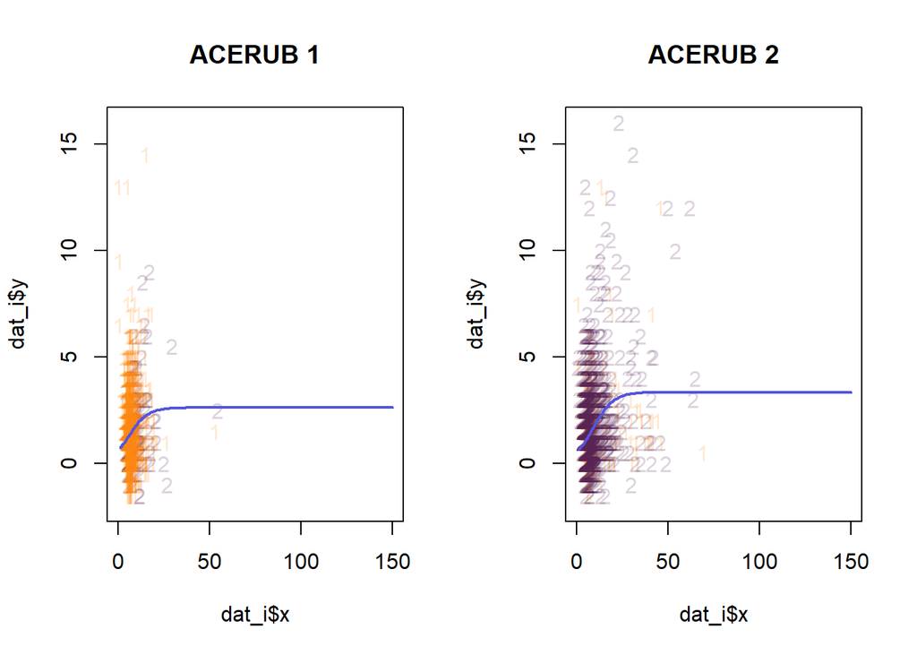

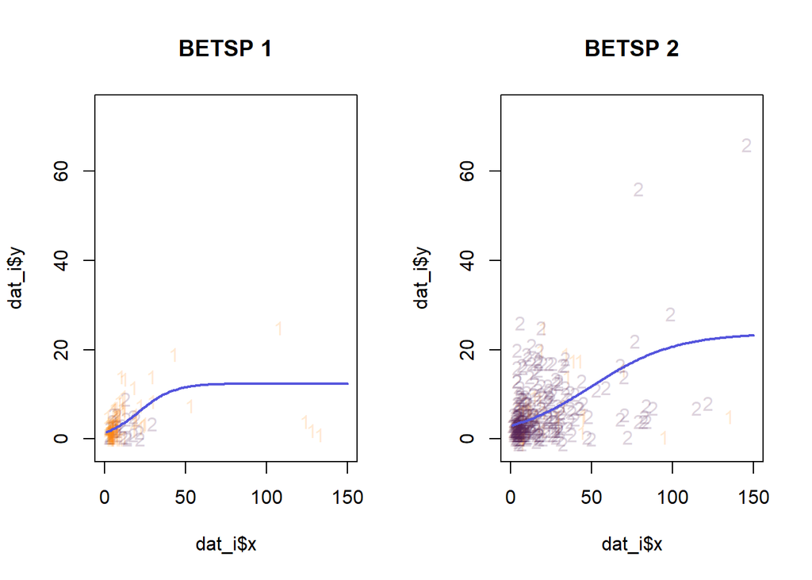

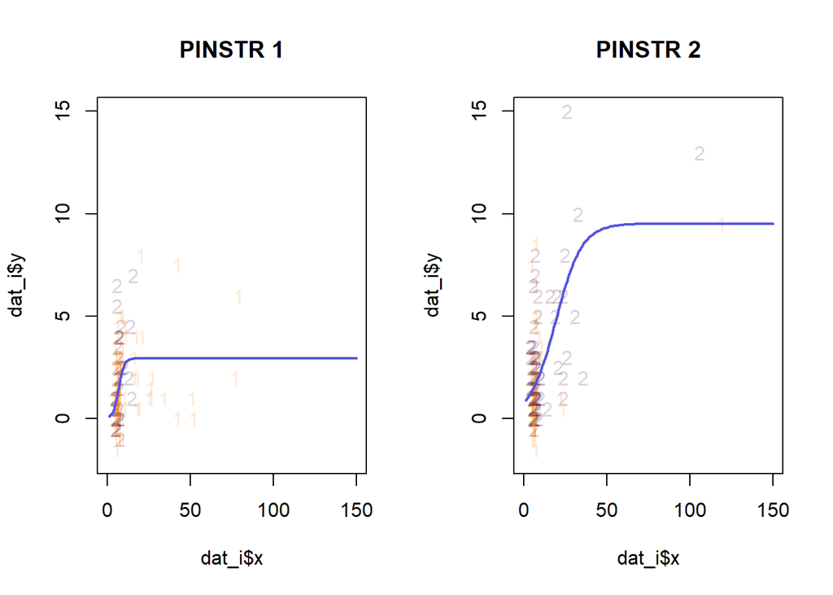

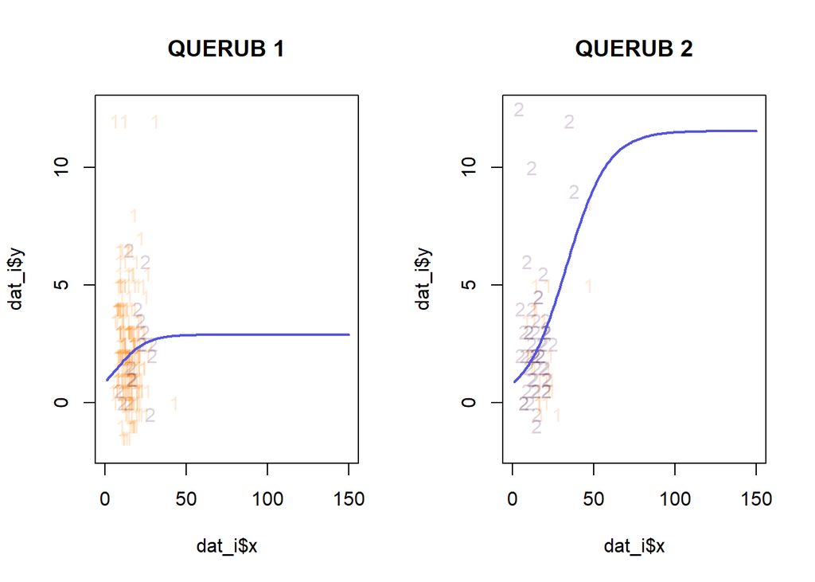

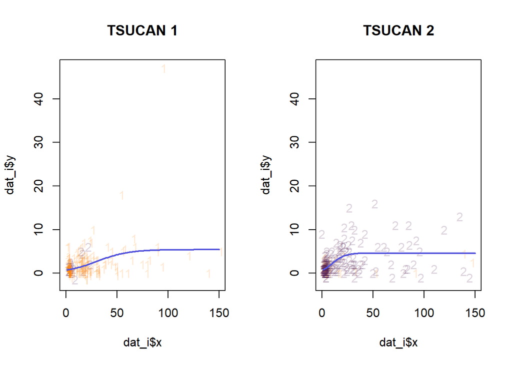

```r
starts        <- read.csv(file = "../Data/nls_starts.csv")
starts.ricker <- read.csv(file = "../Data/nls_ricker_starts.csv")
starts.gompertz <- read.csv(file = "../Data/nls_gompertz_starts.csv")

# Expand starts if using 3 classes.
if(length(canopy) == 3){
  starts          <- starts[         c(1,2,2,3,4,4,5,6,6,7,8,8,9,10,10), ]
  starts.ricker   <- starts.ricker[  c(1,2,2,3,4,4,5,6,6,7,8,8,9,10,10), ]
  starts.gompertz <- starts.gompertz[c(1,2,2,3,4,4,5,6,6,7,8,8,9,10,10), ]
  starts$canopy = starts.ricker$canopy =  starts.gompertz$canopy <- rep(1:3, 5)
}
# Output:

boot_nls <- vector(mode = "list")

xgrid <- seq(from = 0, to = 400, length.out = 101)
bi = 1
si = 1
ci = 1
qr.mods <- data.frame()
qr.logistic <- data.frame()
qr.ricker   <- data.frame()
qr.gompertz <- data.frame()
dat <- list()
si = 1
ci = 1
for(si in 1:length(spp)){
  dat[[si]] <- list()
  par(mfrow = c(1, length(canopy)))

  sp_dat <- A |> filter(Species_23 == spp[si], grow21 > min_grow, grow21 < max_grow, HT_22 >= min_h)
  sp_max_growth <- max(c(sp_dat$grow, sp_dat$grow21), na.rm = T)

  for(ci in 1:length(canopy_list)){
    dat[[si]][[ci]] <- list()

    which_starts   <- which(starts$spp == spp[si] & starts$canopy == canopy[ci])

    # Use gap definition from 2022?
    if(gap22){

      A21_i <- A |> filter(Species_23 == spp[si],
                           Crown_Class_22 %in% canopy_list[[ci]],
                           grow21 > min_grow, grow21 < max_grow,
                           HT_22 >= min_h)

      A22_i <- A |> filter(Species_23 == spp[si],
                     Crown_Class_22 %in% canopy_list[[ci]],
                     grow > min_grow, grow < max_grow,
                     HT_23 >= min_h)

    }else{

      A21_i <- A |> filter(Species_23 == spp[si],
                     Crown_Class_22 %in% canopy_list[[ci]],
                     grow21 > min_grow, grow21 < max_grow,
                     HT_21 >= min_h)

      A22_i <- A |> filter(Species_23 == spp[si],
                     Crown_Class_23 %in% canopy_list[[ci]],
                     grow > min_grow, grow < max_grow,
                     HT_22 >= min_h)

    }


    dat_i = data.frame(x = c(A22_i$HT_22, A21_i$HT_21),
                       y = c(A22_i$grow, A21_i$grow21),
                       p = canopy_classes[match(c(A22_i$Crown_Class_23, A21_i$Crown_Class_22), crown_classes)])

    start_li <- starts[which_starts, c("a", "b", "c")]
    start_ri <- starts.ricker[which_starts, c("a", "b")]
    start_gi <- starts.gompertz[which_starts, c("a", "b", "c")]



    # Initial curves attempted.
    plot(dat_i$x, dat_i$y, xlim = c(0, 150), ylim = c(-2, sp_max_growth), main = paste(spp[si], ci),
         pch = as.character(dat_i$p), col = c("#ff881130", "#55225533")[as.numeric(dat_i$p)])

    dat[[si]][[ci]]$logistic <-
      try(nls(y ~ SSlogis(x, a, b, c), data = dat_i, start = start_li))

    dat[[si]][[ci]]$ricker <- try(nls(y ~ SSricker(x, a, b), data = dat_i, start = start_ri))

    dat[[si]][[ci]]$gompertz <- try(nls(y ~ SSgompertz(x, a, b, c), data = dat_i, start = start_gi))


    dat[[si]][[ci]]$logistic.qr90 <-
      try(nlrq(y ~ SSlogis(x, a, b, c), data = dat_i, start = start_li, tau = tau))

    dat[[si]][[ci]]$ricker.qr90 <- try(nlrq(y ~ SSricker(x, a, b), data = dat_i, start = start_ri, tau = tau))

    dat[[si]][[ci]]$gompertz.qr90 <- try(nlrq(y ~ SSgompertz(x, a, b, c), data = dat_i, start = start_gi, tau = tau))

    # Logistic
    if(is.character(dat[[si]][[ci]]$logistic)){
      print(x = paste("Logistic Not fit:", spp[si], canopy[ci]))

      dat[[si]][[ci]]$logistic.boot <-
        boot(data = dat_i, statistic = boot_stat, R = boots, sim = "parametric",
             # parallel = "multicore", ncpus = 6,
             ran.gen = boot_rand, new_start = start_li)

      cat(paste("\n\033[34mFit Ratio Logistic (boot):\033[0m",
                round(mean(complete.cases(dat[[si]][[ci]]$logistic.boot$t)), 3),
                spp[si], canopy[ci], "\n"))


    }else{

      dat[[si]][[ci]]$logistic.boot <-
        boot(data = dat_i, statistic = boot_stat, R = boots, sim = "parametric",
             ran.gen = boot_rand, new_start = start_li)

      cat(paste("\n\033[34mFit Ratio Logistic:\033[0m",
                round(mean(complete.cases(dat[[si]][[ci]]$logistic.boot$t)), 3),
                spp[si], canopy[ci], "\n"))

    }

    (logis_i <-   apply(dat[[si]][[ci]]$logistic.boot$t, MARGIN = 2, FUN = median, na.rm = T))
    lines(1:150, SSlogis(input = 1:150,
                   Asym = logis_i[1],
                   xmid = logis_i[2],
                   scal = logis_i[3]),
    col = "#5555dd", lwd = 2)

    # Ricker
    if(is.character(dat[[si]][[ci]]$ricker)){
      print(x = paste("Ricker Not fit:", spp[si], canopy[ci]))

      dat[[si]][[ci]]$ricker.boot <-
        boot(data = dat_i, statistic = boot_ricker, R = boots, sim = "parametric",
             ran.gen = boot_rand, new_start = start_ri)

      cat(paste("\n\033[33mFit Ratio Ricker (boot):\033[0m",
                round(mean(complete.cases(dat[[si]][[ci]]$ricker.boot$t)), 3),
                spp[si], canopy[ci], "\n"))

    }else{

      dat[[si]][[ci]]$ricker.boot <- boot_nls(dat[[si]][[ci]]$ricker, R = boots)
      cat(paste("\n\033[33mFit Ratio Ricker:\033[0m",
                round(mean(complete.cases(dat[[si]][[ci]]$ricker.boot$t)), 3),
                spp[si], canopy[ci]))
    }


    # Gompertz
    if(is.character(dat[[si]][[ci]]$gompertz)){
      cat(x = paste("\n\033[32m\nGompertz Not fit:", spp[si], canopy[ci], "\033[0m"))

      dat[[si]][[ci]]$gompertz.boot <-
        boot(data = dat_i, statistic = boot_gompertz, R = boots, sim = "parametric",
             ran.gen = boot_rand, new_start = start_gi, ncpus = 6)

      cat(paste("\n\033[32mFit Ratio Gompertz (boot):\033[0m",
                round(mean(complete.cases(dat[[si]][[ci]]$gompertz.boot$t)), 3),
                spp[si], canopy[ci]),"\n")

    }else{

      dat[[si]][[ci]]$gompertz.boot <- boot_nls(dat[[si]][[ci]]$gompertz, R = boots)
      print(paste("Fit Ratio Gompertz:",
                  round(mean(complete.cases(dat[[si]][[ci]]$gompertz.boot$t)), 3),
                  spp[si], canopy[ci]))
    }


    # Add QR lines:

    if(!is.character(dat[[si]][[ci]]$logistic.qr90)){
      q90_coef <- coef(dat[[si]][[ci]]$logistic.qr90)

      qr.mod <- data.frame(mod = "logistic", species = si, canopy = ci, quantile = tau)
      qr.mod[1, c("a", "b", "c")] <- q90_coef
      qr.mods <- rbind(qr.mods, qr.mod)
      qr.logistic <- rbind(qr.logistic, qr.mod)

    }else{
      qr.mod <- data.frame(mod = "logistic", species = si, canopy = ci, quantile = tau)
      qr.mod[1, c("a", "b", "c")] <- rep(NA, 3)
      qr.mods <- rbind(qr.mods, qr.mod)
      qr.logistic <- rbind(qr.logistic, qr.mod)
    }

    # Q90 Ricker
    if(!is.character(dat[[si]][[ci]]$ricker.qr90)){
      q90_coef <- coef(dat[[si]][[ci]]$ricker.qr90)

      qr.mod <- data.frame(mod = "ricker", species = si, canopy = ci, quantile = tau)
      qr.mod[1, c("a", "b", "c")] <- c(q90_coef, c = NA)
      qr.mods <- rbind(qr.mods, qr.mod)
      qr.ricker <- rbind(qr.ricker, qr.mod)

    }else{
      qr.mod <- data.frame(mod = "ricker", species = si, canopy = ci, quantile = tau)
      qr.mod[1, c("a", "b", "c")] <- rep(NA, 3)
      qr.mods <- rbind(qr.mods, qr.mod)
      qr.ricker <- rbind(qr.ricker, qr.mod)
    }

    #Q90 Gompertz
    if(!is.character(dat[[si]][[ci]]$gompertz.qr90)){
      q90_coef <- coef(dat[[si]][[ci]]$gompertz.qr90)

      qr.mod <- data.frame(mod = "gompertz", species = si, canopy = ci, quantile = tau)
      qr.mod[1, c("a", "b", "c")] <- q90_coef
      qr.mods <- rbind(qr.mods, qr.mod)
      qr.gompertz <- rbind(qr.gompertz, qr.mod)
    }else{
      qr.mod <- data.frame(mod = "gompertz", species = si, canopy = ci, quantile = tau)
      qr.mod[1, c("a", "b", "c")] <- rep(NA, 3)
      qr.mods <- rbind(qr.mods, qr.mod)
      qr.gompertz <- rbind(qr.gompertz, qr.mod)
    }

  }

}
```

**Bootstrapping of growth models**

```r
par(mfrow = c(1, 1))


write.csv(file = paste0("../Data/Output/quantile", tau, ".csv"), x = qr.mods)
```

**Parameters fit and model output**

```r
logistic_result <- data.frame()
ricker_result   <- data.frame()
gompertz_result   <- data.frame()

si = 1; ci = 1
for(si in 1:length(spp)){
  for(ci in 1:length(canopy)){
    logistic_ti  <- dat[[si]][[ci]]$logistic.boot$t
    ricker_ti   <- dat[[si]][[ci]]$ricker.boot$t
    gompertz_ti   <- dat[[si]][[ci]]$gompertz.boot$t

    logistic_ti <- cbind(rep(si, nrow(logistic_ti)) , rep(ci, nrow(logistic_ti)), logistic_ti)
    ricker_ti   <- cbind(rep(si, nrow(ricker_ti)),    rep(ci, nrow(ricker_ti)),   ricker_ti)
    gompertz_ti   <- cbind(rep(si, nrow(gompertz_ti)),    rep(ci, nrow(gompertz_ti)),   gompertz_ti)

    logistic_result <- rbind(logistic_result, logistic_ti[complete.cases(logistic_ti), ])
    ricker_result   <- rbind(ricker_result, ricker_ti[complete.cases(ricker_ti), ])
    gompertz_result   <- rbind(gompertz_result, gompertz_ti[complete.cases(gompertz_ti), , drop = F])


  }
}



names(logistic_result) <- c("spp", "canopy", "a", "b", "c")
names(ricker_result)   <- c("spp", "canopy", "a", "b")
names(gompertz_result)   <- c("spp", "canopy", "a", "b", "c")

logistic_table <- logistic_result |> group_by(spp, canopy) |>
  summarise(
    a.mu = mean(a),
    a.sd = sd(a),
    a.05 = quantile(a, probs = 0.05),
    a.50 = quantile(a, probs = 0.50),
    a.95 = quantile(a, probs = 0.95),
    b.mu = mean(b),
    b.sd = sd(b),
    b.05 = quantile(b, probs = 0.05),
    b.50 = quantile(b, probs = 0.50),
    b.95 = quantile(b, probs = 0.95),
    c.mu = mean(c),
    c.sd = sd(c),
    c.05 = quantile(c, probs = 0.05),
    c.50 = quantile(c, probs = 0.50),
    c.95 = quantile(c, probs = 0.95),
  ) |>
  mutate(spp = spp_names[spp])
panderOptions('table.split.table', Inf)
pander(logistic_table, caption = "Logistic Coefficients")
```

Logistic Coefficients

| spp | canopy | a.mu | a.sd | a.05 | a.50 | a.95 | b.mu | b.sd | b.05 | b.50 | b.95 | c.mu | c.sd | c.05 | c.50 | c.95 |
| --- | --- | --- | --- | --- | --- | --- | --- | --- | --- | --- | --- | --- | --- | --- | --- | --- |
| ACERUB | 1 | 3.101 | 1.92 | 1.431 | 2.611 | 6.138 | 5.657 | 9.214 | -8.009 | 5.971 | 18.62 | 6.93 | 6.144 | 1.064 | 5.117 | 18.24 |
| ACERUB | 2 | 4.224 | 3.907 | 1.852 | 3.335 | 8.671 | 10.65 | 9.441 | 1.265 | 9.067 | 27.11 | 7.309 | 5.718 | 2.158 | 5.47 | 18.36 |
| BETSP | 1 | 17.11 | 48.17 | 4.887 | 12.39 | 31.29 | 37.64 | 57.53 | 5.423 | 21.44 | 146.4 | 15.41 | 19.96 | 1.583 | 10.65 | 60.01 |
| BETSP | 2 | 36.18 | 64.49 | 6.969 | 23.66 | 91.87 | 85.2 | 119.2 | 3.809 | 50 | 305.8 | 37.24 | 38.68 | 2.763 | 25.82 | 121.2 |
| PINSTR | 1 | 4.213 | 22.3 | 1.803 | 2.939 | 6.566 | 9.231 | 10.63 | 5.132 | 6.792 | 22.81 | 2.668 | 4.48 | 0.3099 | 1.619 | 10.58 |
| PINSTR | 2 | 9.588 | 9.672 | 2.906 | 9.514 | 15.37 | 23.88 | 22.65 | 5.918 | 19.06 | 59.81 | 9.817 | 8.739 | 1.302 | 7.865 | 27.43 |
| QUERUB | 1 | 4.482 | 4.96 | 2.009 | 2.882 | 11.64 | 14.28 | 21.09 | -1.176 | 7.363 | 47.41 | 12.32 | 13.98 | 0.09001 | 8.778 | 38.28 |
| QUERUB | 2 | 13.65 | 8.947 | 4.278 | 11.56 | 26.87 | 36.9 | 17.48 | 9.89 | 33.05 | 69.26 | 14.12 | 6.166 | 5.9 | 12.74 | 25.5 |
| TSUCAN | 1 | 8.312 | 11.86 | 2.126 | 5.399 | 20.84 | 44.58 | 52.87 | 4.261 | 29.88 | 133.7 | 20.73 | 17.88 | 3.121 | 15.54 | 58.55 |
| TSUCAN | 2 | 8.965 | 22.25 | 2.597 | 4.589 | 28.27 | 31.15 | 54.19 | 3.4 | 10.34 | 166.5 | 14.33 | 18.61 | 2.393 | 5.98 | 57.88 |

**Parameters fit and model output**

```r
canopy_state <- ifelse(test = gap22, yes = "_2022_canopy", no = "")
write.csv(x = logistic_table, file = paste0("../Data/Output/nls_logistic_curves", boots, canopy_state, ".csv"), row.names = F)

# Ricker:

ricker_table <- ricker_result |> group_by(spp, canopy) |>
  summarise(
    a.mu = mean(a),
    a.sd = sd(a),
    a.05 = quantile(a, probs = 0.05),
    a.50 = quantile(a, probs = 0.50),
    a.95 = quantile(a, probs = 0.95),
    b.mu = mean(b),
    b.sd = sd(b),
    b.05 = quantile(b, probs = 0.05),
    b.50 = quantile(b, probs = 0.50),
    b.95 = quantile(b, probs = 0.95),
  ) |>
  mutate(spp = spp_names[spp])

if(simulate_ricker == T){
  pander(ricker_table, caption = "Ricker Coefficients")
}
write.csv(x = ricker_table, file = paste0("../Data/Output/nls_curves", boots, canopy_state, ".csv"), row.names = F)

# Gompertz
gompertz_table <- gompertz_result |> group_by(spp, canopy) |>
  summarise(
    a.mu = mean(a),
    a.sd = sd(a),
    a.05 = quantile(a, probs = 0.05),
    a.50 = quantile(a, probs = 0.50),
    a.95 = quantile(a, probs = 0.95),
    b.mu = mean(b),
    b.sd = sd(b),
    b.05 = quantile(b, probs = 0.05),
    b.50 = quantile(b, probs = 0.50),
    b.95 = quantile(b, probs = 0.95),
    c.mu = mean(c),
    c.sd = sd(c),
    c.05 = quantile(c, probs = 0.05),
    c.50 = quantile(c, probs = 0.50),
    c.95 = quantile(c, probs = 0.95),
  ) |>
  mutate(spp = spp_names[spp])
panderOptions('table.split.table', Inf)
if(simulate_gompertz == T){
  pander(gompertz_table, caption = "Gompertz Coefficients")
}
write.csv(x = gompertz_table, file = paste0("../Data/Output/nls_gompertz_curves", boots, canopy_state, ".csv"), row.names = F)
```

**Logistic models fit**

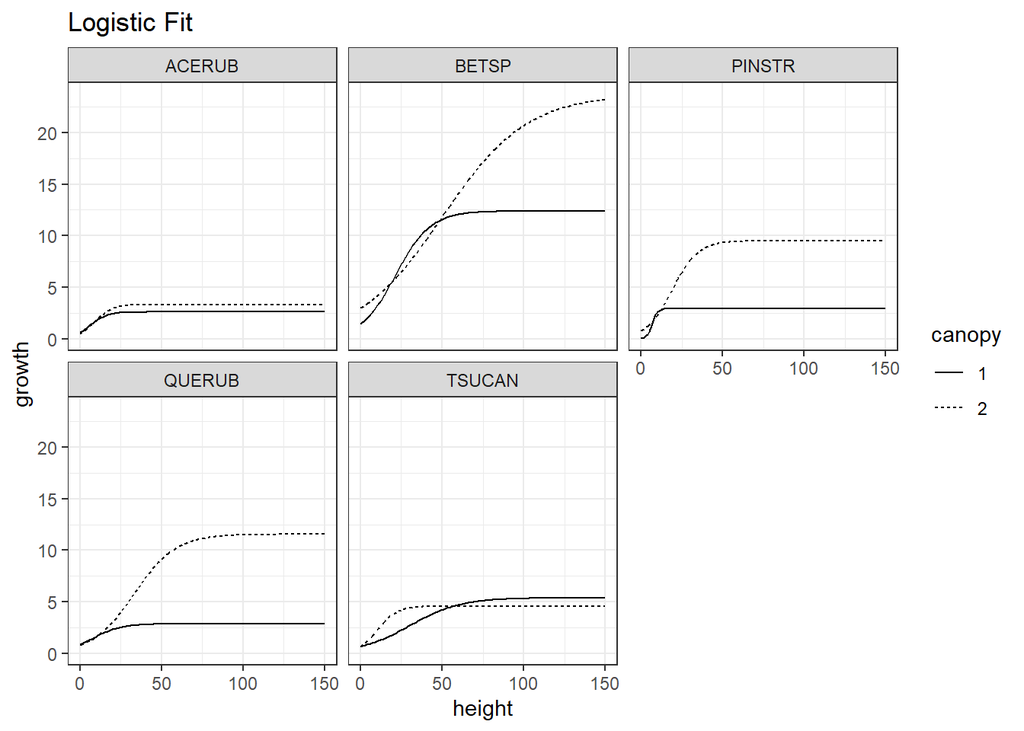

```r
dat_s <- logistic_table
hgrid <- seq(from = 0, to = 300, length.out = 301)
grid_fit <- data.frame()

i = 1
sp_seq <- rep(1:5, each = length(canopy))
for(i in 1:nrow(dat_s)){
  y_out <- SSlogis(input = hgrid,
                   Asym = dat_s[i, "a.50"][[1]],
                   xmid = dat_s[i, "b.50"][[1]],
                   scal = dat_s[i, "c.50"][[1]])

  if(!is.character(dat[[sp_seq[i]]][[dat_s$canopy[i]]]$logistic)){
    # Fit curve:
    coef_i <- coef(dat[[sp_seq[i]]][[dat_s$canopy[i]]]$logistic)
    l_out <- SSlogis(input = hgrid,
                     Asym = coef_i[[1]],
                     xmid = coef_i[[2]],
                     scal = coef_i[[3]])
  }else{
    l_out <- rep(x = NA, length(hgrid))
  }

  if(!is.character(dat[[sp_seq[i]]][[dat_s$canopy[i]]]$logistic.qr90)){
    coef_i <- coef(dat[[sp_seq[i]]][[dat_s$canopy[i]]]$logistic.qr90)
    # Fit curve:
    q_out <- SSlogis(input = hgrid,
                     Asym = coef_i[[1]],
                     xmid = coef_i[[2]],
                     scal = coef_i[[3]])
  }else{
    q_out <- rep(x = NA, length(hgrid))
  }

  grid_i <- data.frame(height = hgrid,
                       growth = y_out,
                       growth.mean = l_out,
                       growth.q90 = q_out,
                       spp = dat_s[i, "spp"],
                       canopy = dat_s[i, "canopy"],
                       model = "Logistic")
  grid_fit <- rbind(grid_fit, grid_i)
}

ggplot(grid_fit |> mutate(canopy = factor(canopy)),
       mapping = aes(x = height, y = growth)) +
  geom_line(mapping = aes(lty = canopy)) +
  facet_wrap(~spp) +
  theme_bw() + labs(title = "Logistic Fit") +
  lims(x = c(0, 150))
```

### Acer rubrum

**Acer rubrum growth curve overlaid on data**

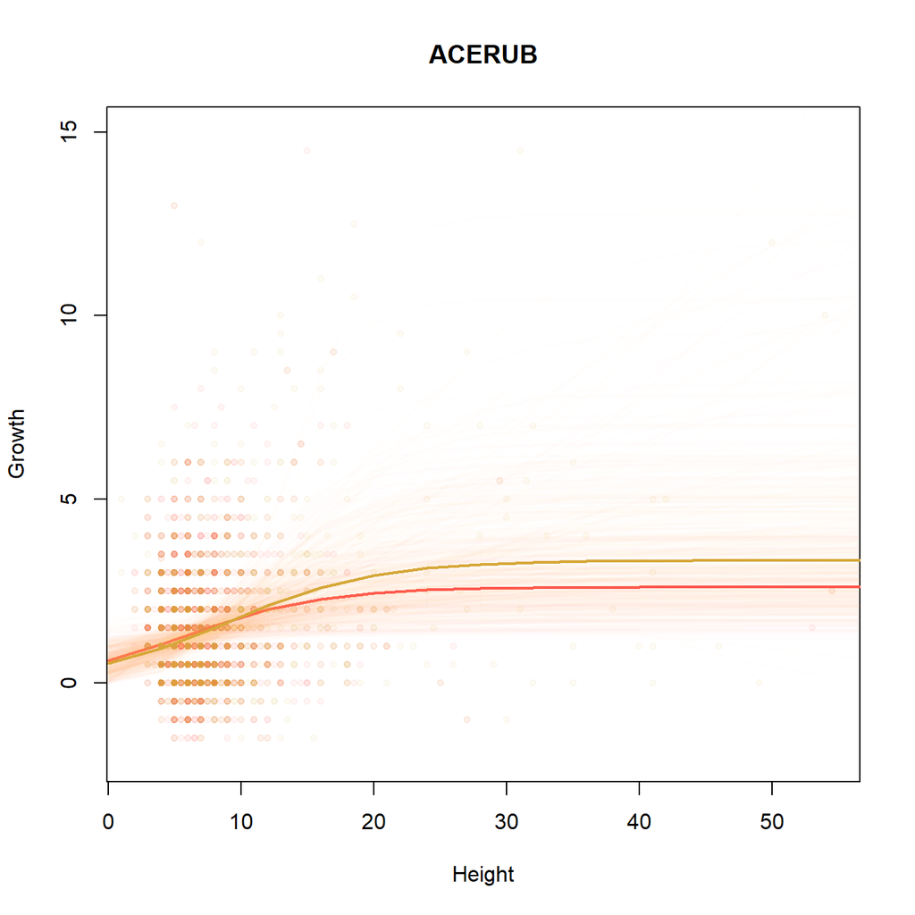

```r
par(mfrow = c(1, 1))
si = 1
plot_spp(si = si, line_alpha = 0.01, point_alpha = 0.05, max_grow = 15)
```

**Acer rubrum histogram for parameters**

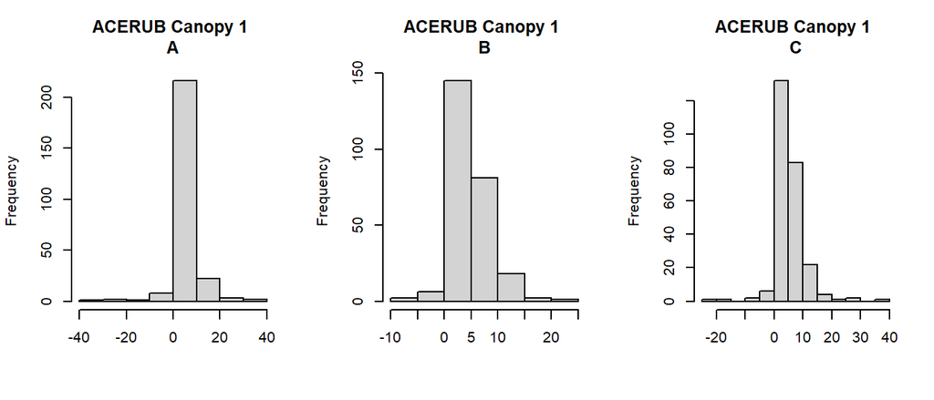

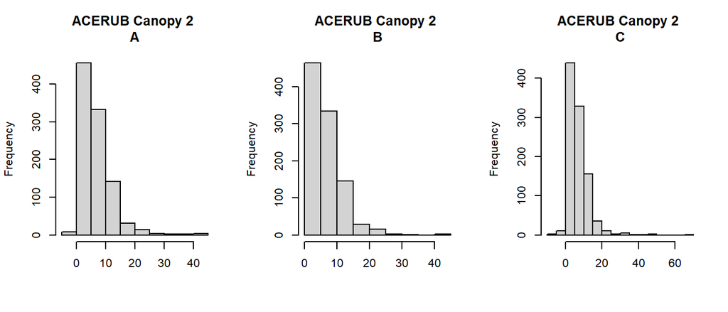

```r
for(ci in 1:length(canopy)){
  try(plot_par(par_dat = dat[[si]][[ci]]$logistic.boot$t,
               par_names = paste(spp[si], "Canopy", canopy[ci], c("\nA", "\nB", "\nC"))))
}
```

### Betula spp.

**Betula species curves overlaid on data**

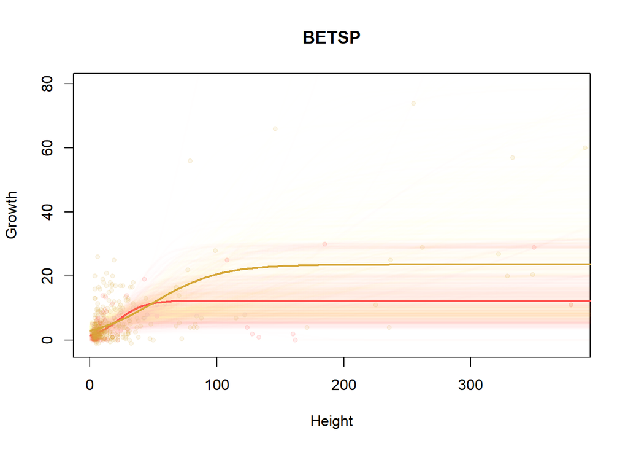

```r
si = 2
plot_spp(si = si, line_alpha = 0.005, point_alpha = 0.1, max_grow = 80)
```

**Betula species paramter histograms**

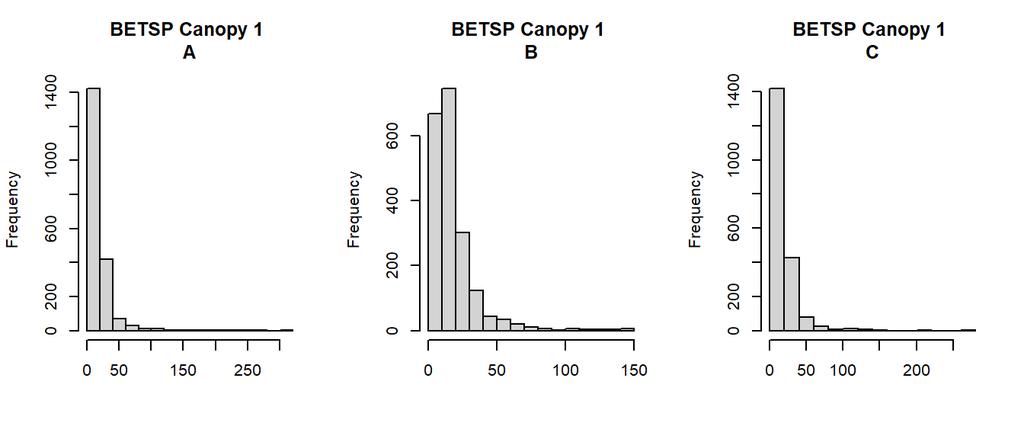

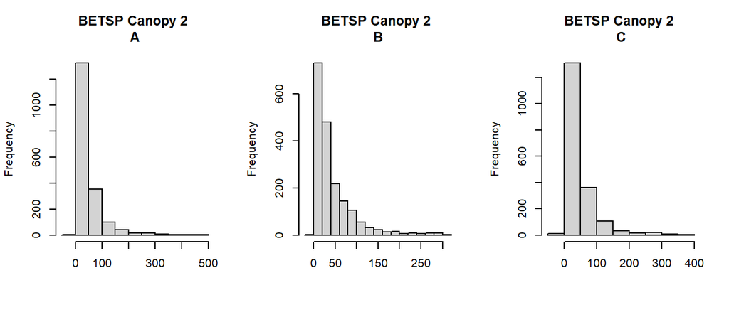

```r
for(ci in 1:length(canopy)){
  try(plot_par(par_dat = dat[[si]][[ci]]$logistic.boot$t,
               par_names = paste(spp[si], "Canopy", canopy[ci], c("\nA", "\nB", "\nC"))))
}
```

### Pinus strobus

**Pinus strobus curves overlaid on data**

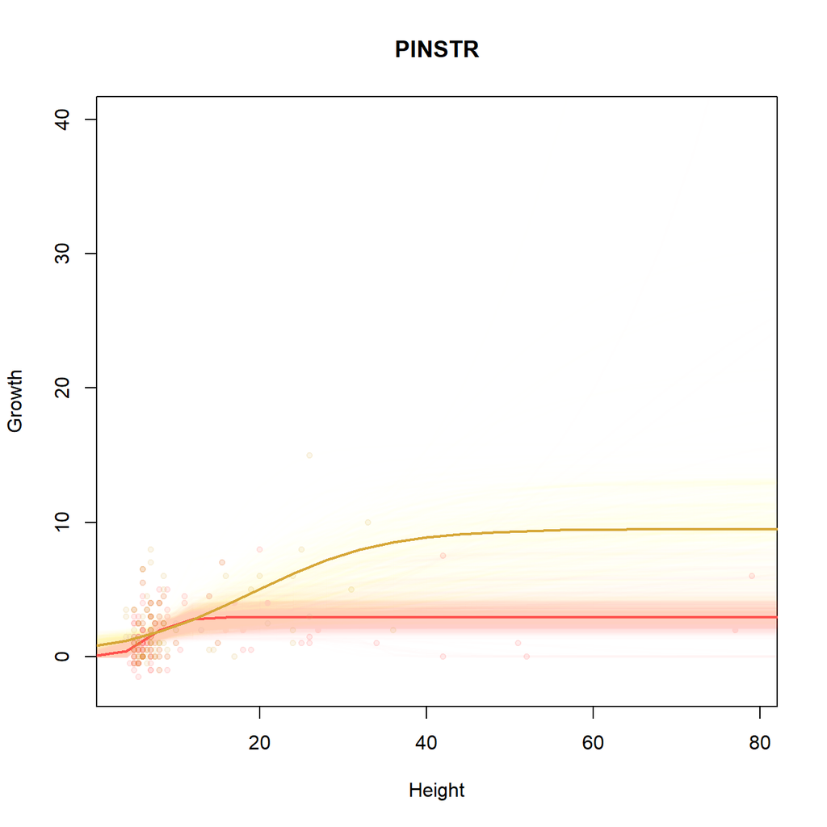

```r
si = 3
plot_spp(si = si, line_alpha = 0.0025, point_alpha = 0.1)
```

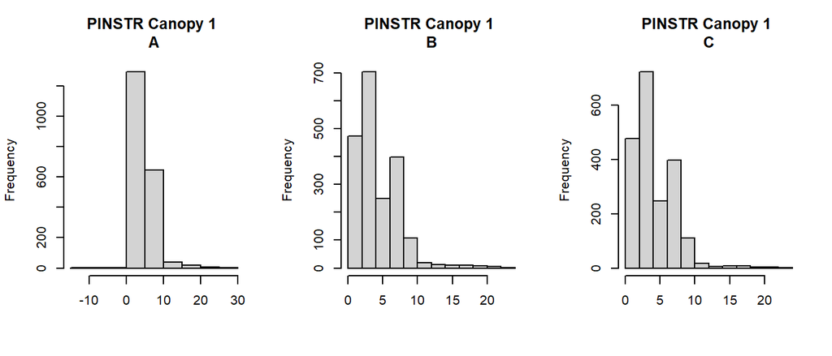

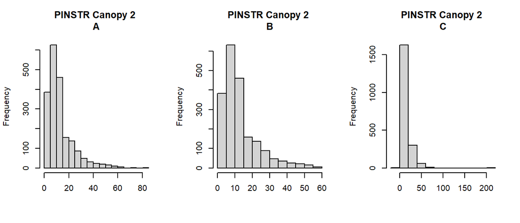

```r
for(ci in 1:length(canopy)){
  try(plot_par(par_dat = dat[[si]][[ci]]$logistic.boot$t,
               par_names = paste(spp[si], "Canopy", canopy[ci], c("\nA", "\nB", "\nC"))))
}
```

### Quercus rubra

**Quercus rubra curves overlaid on data**

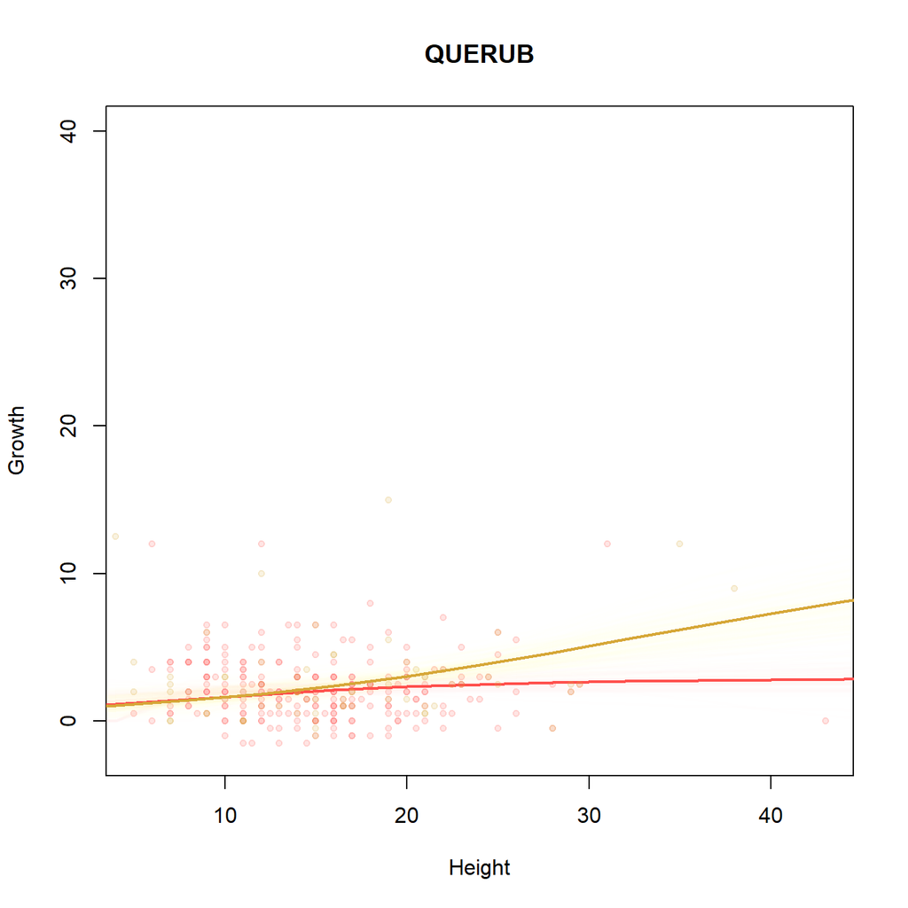

```r
si = 4
plot_spp(si = si, line_alpha = 0.005, point_alpha = 0.15)
```

**Quercus rubra parameter histogram**

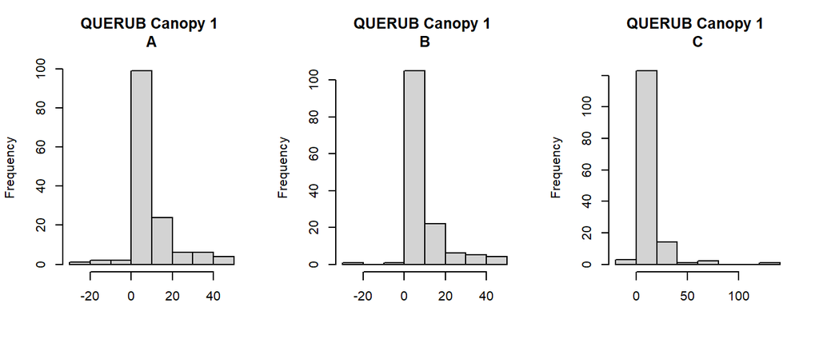

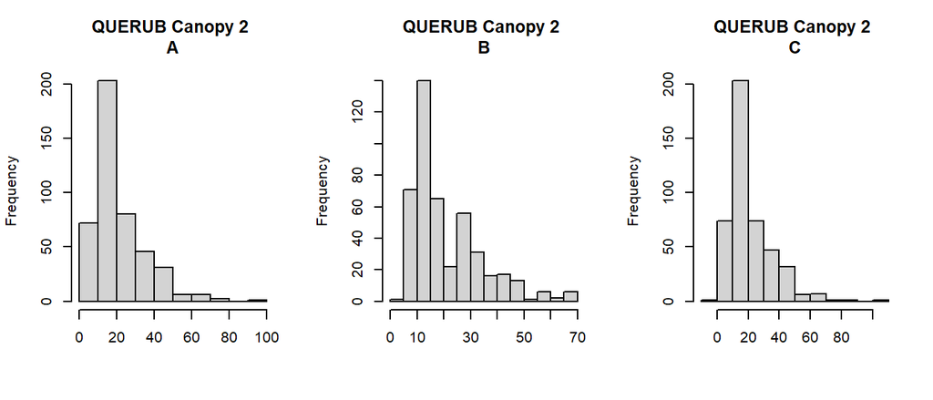

```r
for(ci in 1:length(canopy)){
  try(plot_par(par_dat = dat[[si]][[ci]]$logistic.boot$t,
               par_names = paste(spp[si], "Canopy", canopy[ci], c("\nA", "\nB", "\nC"))))
}
```

### Tsuga canadensis

**Tsuga canadensis curves overlaid on data**

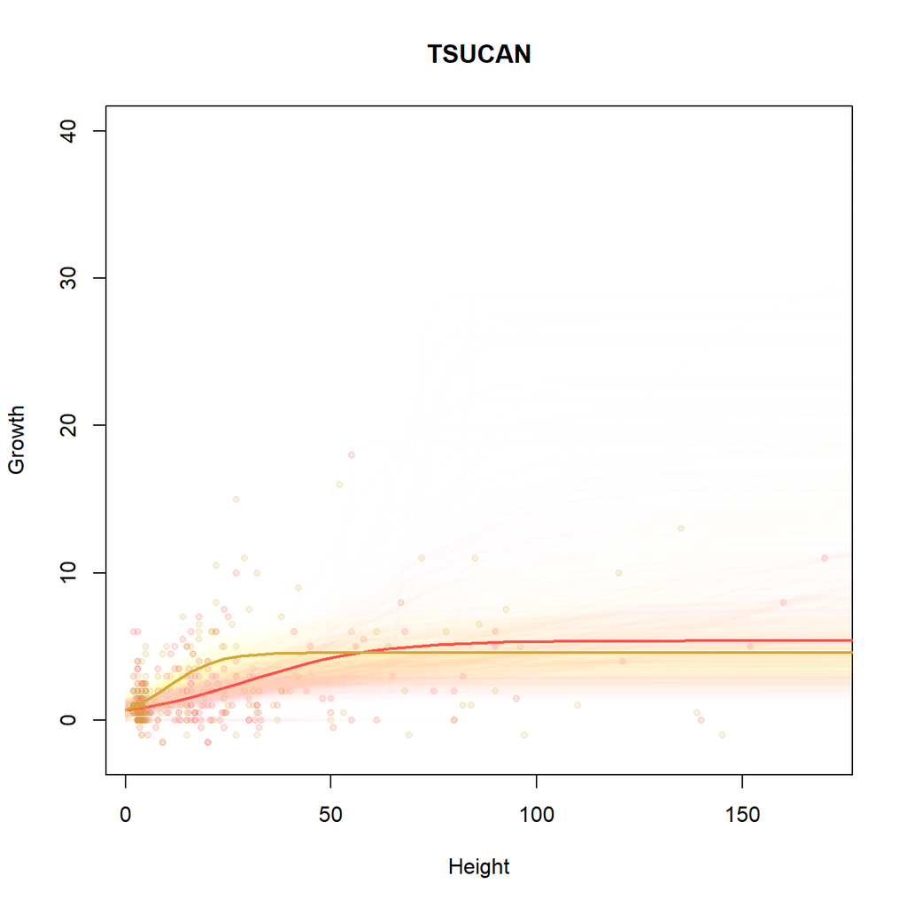

```r
si = 5
plot_spp(si, line_alpha = 0.0025, point_alpha = 0.15)
```

**Tsuga canadensis parameter histogram**

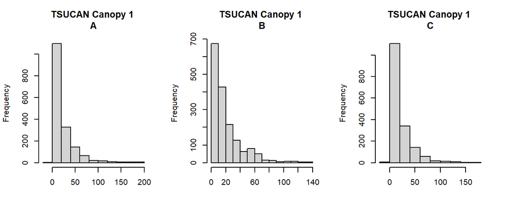

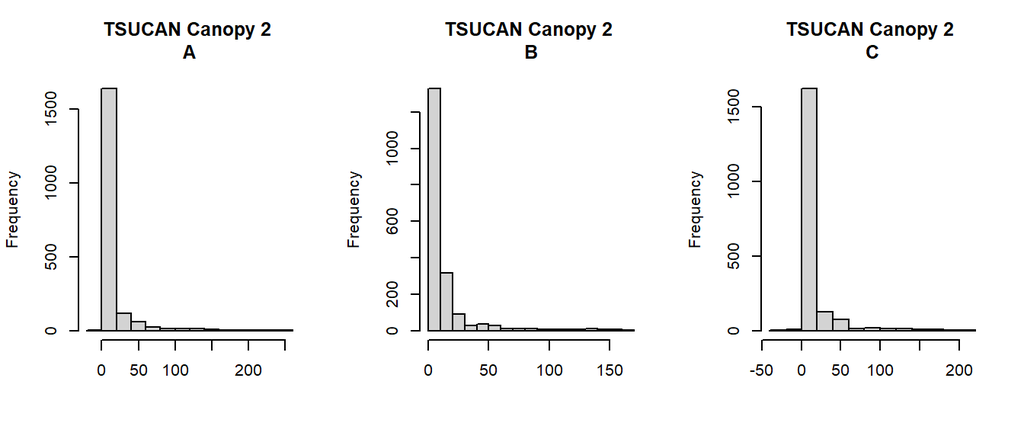

```r
for(ci in 1:length(canopy)){
  try(plot_par(par_dat = dat[[si]][[ci]]$logistic.boot$t,
               par_names = paste(spp[si], "Canopy", canopy[ci], c("\nA", "\nB", "\nC"))))
}
```

# Simulations

**Individual based model**

```r
# Growth parameters
logistic_table$species <- rep(1:5, each = length(canopy_list))
ricker_table$species   <- rep(1:5, each = length(canopy_list))
gompertz_table$species <- rep(1:5, each = length(canopy_list))



# Assuming the growth_function4.R file is available and properly defined.
source("../Code/growth_function4.R")

num_to_ht <- numeric(trials)
num_needed <- numeric(trials)
time_to_ht <- numeric(trials)

# Create an empty matrix to store results
result_matrix <- matrix(NA, ncol = 7, nrow = length(spp) * length(canopy))
colnames(result_matrix) <- c("num_to_ht", "num_needed",
                             "min_time_to_ht", "med_time_to_ht",
                             "species", "canopy", "trial")

logistic_matrix <- ricker_matrix <- gompertz_matrix <- result_matrix

result_set <- data.frame()

## trials
# Loop through each species
si = 1; ci = 1; ti = 1
for(ti in 1:trials){
  for (si in 1:length(spp)) {
  # Loop through each canopy
    for (ci in 1:length(canopy)) {
      which_grow_var <- which(grow_var$Species == spp[si] & grow_var$Canopy == canopy[ci])

      # Extract a0 and a1 values from dat_surv for the specific species and canopy
      a0 <- dat_surv$estimate[dat_surv$spp == si & dat_surv$canopy == ci & dat_surv$term == "(Intercept)"]
      a1 <- dat_surv$estimate[dat_surv$spp == si & dat_surv$canopy == ci & dat_surv$term == "HT1"]
      # a1 = .10

      if(seedling_variance == F){
        par_se = 0  ## Fixed growth correlation coefficient
      }else{
        par_se = grow_var$sd[which_grow_var]  ## growth correlation coefficient
      }

      # Specify ht2 based on species --stochastic --give different hts for all initial seedlings
      sp_set <- rep(si, n_seedling)
      ht <- get_ht(sp_n = sp_set)


      if(breakage == F){
        break_mean = 0
        break_prop = 0
      }else{
        break_mean <- psurv_spp[[si, "mu.break"]]
        break_prop <- psurv_spp[[si, "mu.prop_break"]]
      }

      if(sample_curves == T){
        logistic_samp <- logistic_result |> filter(spp == si, canopy == ci) |>
        sample_n(size = n_seedling, replace = T)
        par_se <- 0 # Remove the random effect, replace with curve sampling.
      }else{
        logistic_samp <- data.frame(
            a = rep(logistic_table$a.mu[logistic_table$spp == spp[si] &
                                          logistic_table$canopy == ci], n_seedling),
            b = rep(logistic_table$b.mu[logistic_table$spp == spp[si] &
                                          logistic_table$canopy == ci], n_seedling),
            c = rep(logistic_table$c.mu[logistic_table$spp == spp[si] &
                                          logistic_table$canopy == ci], n_seedling)
          )
        # logistic_result |> filter(spp == si, canopy == ci) |>
        # sample_n(size = n_seedling, replace = T)
      }


      result_logistic <- simulate_tree_growth(
        t = timesteps, n = n_seedling,
        a0 = a0, a1 = a1,
        a = logistic_samp$a,
        b = logistic_samp$b,
        c = logistic_samp$c,
        ht_initial = ht, sd = par_se,
        msurv = surv_props$surv_sp_canopy_max[surv_props$spp == si & surv_props$canopy == ci],
        break_mean = break_mean,
        break_prop = break_prop,
        form = "logistic")

      if(simulate_ricker == T){
        result_ricker <- simulate_tree_growth(
        t = timesteps, n = n_seedling,
        a0 = a0, a1 = a1,
        a = rep(ricker_table$a.mu[ricker_table$spp == spp[si] & ricker_table$canopy == ci], n_seedling),
        b = rep(ricker_table$b.mu[ricker_table$spp == spp[si] & ricker_table$canopy == ci], n_seedling),
        c = rep(NA, n_seedling),
        ht_initial = ht, sd = par_se,
        msurv = surv_props$surv_sp_canopy_max[surv_props$spp == si & surv_props$canopy == ci],
        break_mean = break_mean,
        break_prop = break_prop,
        form = "ricker")

        ricker_matrix[index, ]   <- c(summarise_results(result_ricker  ), si, ci, ti)
        # cat(".")
      }


      if(simulate_gompertz == T){
        result_gompertz <- simulate_tree_growth(
        t = timesteps, n = n_seedling,
        a0 = a0, a1 = a1,
        a = rep(gompertz_table$a.mu[gompertz_table$spp == spp[si] & gompertz_table$canopy == ci], n_seedling),
        b = rep(gompertz_table$b.mu[gompertz_table$spp == spp[si] & gompertz_table$canopy == ci], n_seedling),
        c = rep(gompertz_table$c.mu[gompertz_table$spp == spp[si] & gompertz_table$canopy == ci], n_seedling),
        ht_initial = ht, sd = par_se,
        msurv = surv_props$surv_sp_canopy_max[surv_props$spp == si & surv_props$canopy == ci],
        break_mean = break_mean,
        break_prop = break_prop,
        form = "gompertz")

        gompertz_matrix[index, ] <- c(summarise_results(result_gompertz), si, ci, ti)
        # cat(".")
      }


      # Calculate the index for storing results
      index <- (si - 1) * length(canopy) + ci

      # Store results in the matrix
      logistic_matrix[index, ] <- c(summarise_results(result_logistic), si, ci, ti)

      if(store_simulation == T){

        scenario <- paste(spp_names[si], ci, "- trial", ti)
        save(list = c("result_logistic", "scenario"),
             file = paste0("../Data/Output/Simulation/Logistic_", spp_names[si], ci, "_t", ti, ".Rdata"))
      }

      simulation_ID <- ti

      # cat(paste0(ci, ", "))
    } # Canopy

    # cat(paste0(spp[si], " "))
  } # Species

  write.csv(x = logistic_matrix,
            file = paste0("../Data/Output/Model/Logistic_",sim_id,"_", ti, ".csv"), row.names = F)

  if(simulate_ricker){
    write.csv(x = ricker_matrix,
            file = paste0("../Data/Output/Model/Ricker_",sim_id,"_", ti, ".csv"), row.names = F)

  }

  if(simulate_gompertz){
    write.csv(x = gompertz_matrix,
            file = paste0("../Data/Output/Model/Gompertz_",sim_id,"_", ti, ".csv"), row.names = F)

  }

} # Trial
```

## Simulation results

**Logistic models**

```r
logistic_trials <- data.frame()
for(ti in 1:trials){
    trial_i <- read.csv(file = paste0("../Data/Output/Model/Logistic_",sim_id,"_", ti, ".csv"))
      logistic_trials <- rbind(logistic_trials, trial_i)
}

summary_df <- logistic_trials |> mutate(species = spp[species]) |> group_by(species, canopy) |>
  summarise(num_to_ht = median(num_to_ht, na.rm = T),
            num_needed = median(num_needed, na.rm = T),
            min_time_to_ht = median(min_time_to_ht, na.rm = T) ,
            med_time_to_ht = median(med_time_to_ht, na.rm = T) ,
            trials = max(trial), .groups = "drop")


overall_df <- logistic_trials |> mutate(species = spp[species]) |>
  # group_by(species, canopy) |>
  summarise(num_to_ht = median(num_to_ht, na.rm = T),
            num_needed = median(num_needed, na.rm = T),
            min_time_to_ht = median(min_time_to_ht, na.rm = T) ,
            med_time_to_ht = median(med_time_to_ht, na.rm = T) ,
            trials = max(trial), .groups = "drop")

gap_df <- logistic_trials |> mutate(species = spp[species]) |>
  group_by(canopy) |>
  summarise(num_to_ht = median(num_to_ht, na.rm = T),
            num_needed = median(num_needed, na.rm = T),
            min_time_to_ht = median(min_time_to_ht, na.rm = T) ,
            med_time_to_ht = median(med_time_to_ht, na.rm = T) ,
            trials = max(trial), .groups = "drop")

overall_df <- logistic_trials |> mutate(species = spp[species]) |>
  summarise(num_to_ht = median(num_to_ht, na.rm = T),
            num_needed = median(num_needed, na.rm = T),
            min_time_to_ht = median(min_time_to_ht, na.rm = T) ,
            med_time_to_ht = median(med_time_to_ht, na.rm = T) ,
            trials = max(trial), .groups = "drop")


pander(summary_df, caption = "Species x Gap median")
```

Species x Gap median

| species | canopy | num_to_ht | num_needed | min_time_to_ht | med_time_to_ht | trials |
| --- | --- | --- | --- | --- | --- | --- |
| ACERUB | 1 | 12 | 833.3 | 22 | 35 | 100 |
| ACERUB | 2 | 35 | 285.7 | 17 | 36 | 100 |
| BETSP | 1 | 43 | 232.6 | 13 | 22 | 100 |
| BETSP | 2 | 1350 | 7.405 | 10 | 29 | 100 |
| PINSTR | 1 | 4 | 2500 | 23 | 32 | 100 |
| PINSTR | 2 | 159 | 62.89 | 13 | 26 | 100 |
| QUERUB | 1 | 0 | Inf | 24 | 26.25 | 100 |
| QUERUB | 2 | 11 | 909.1 | 15 | 21 | 100 |
| TSUCAN | 1 | 0 | Inf | 43 | 48.25 | 100 |
| TSUCAN | 2 | 8 | 1250 | 27 | 41 | 100 |

**Logistic models**

```r
pander(gap_df, caption = "Gap median")
```

Gap median

| canopy | num_to_ht | num_needed | min_time_to_ht | med_time_to_ht | trials |
| --- | --- | --- | --- | --- | --- |
| 1 | 4 | 2500 | 22 | 32.5 | 100 |
| 2 | 35 | 285.7 | 15 | 29 | 100 |

**Logistic models**

```r
pander(overall_df, caption = "Overall median")
```

Overall median

| num_to_ht | num_needed | min_time_to_ht | med_time_to_ht | trials |
| --- | --- | --- | --- | --- |
| 11 | 909.1 | 17 | 30 | 100 |

**Logistic models**

```r
write.csv(x = summary_df, file = paste0("../Data/Output/IBM_logistic_",sim_id,  ".csv"))
write.csv(x = logistic_trials, file = paste0("../Data/Output/IBM_logistic_",sim_id,  "_combined.csv"))
```

**Output for other functional forms (if fit)**

```r
if(simulate_ricker){

  ricker_trials <- data.frame()

  for(ti in 1:trials){
    for(si in 1:length(spp)){
      for(ci in 1:length(canopy)){
        # working with naming structure above,
        trial_i <- read.csv(file = paste0("../Data/Output/Model/Ricker_",sim_id,"_", ti, ".csv"))
        ricker_trials <- rbind(ricker_trials, trial_i)
      }
    }
  }

  ricker_summary <- ricker_trials |> mutate(species = spp[species]) |> group_by(species, canopy) |>
    summarise(num_to_ht = median(num_to_ht, na.rm = T),
              num_needed = median(num_needed, na.rm = T),
              min_time_to_ht = median(min_time_to_ht, na.rm = T) ,
              med_time_to_ht = median(med_time_to_ht, na.rm = T) ,
              trials = max(trial), .groups = "drop")

    pander(ricker_summary, caption = "Ricker IBM results")
  }

  if(simulate_gompertz){

    gompertz_trials <- data.frame()

    for(ti in 1:trials){
      for(si in 1:length(spp)){
        for(ci in 1:length(canopy)){

          # working with naming structure above,
          trial_i <- read.csv(file = paste0("../Data/Output/Model/Gompertz_", sim_id, "_", ti, ".csv"))
          gompertz_trials <- rbind(gompertz_trials, trial_i)
        }
      }
    }

    gompertz_summary <- gompertz_trials |> mutate(species = spp[species]) |> group_by(species, canopy) |>
      summarise(num_to_ht = median(num_to_ht, na.rm = T),
                num_needed = median(num_needed, na.rm = T),
                min_time_to_ht = median(min_time_to_ht, na.rm = T) ,
                med_time_to_ht = median(med_time_to_ht, na.rm = T) ,
                trials = max(trial), .groups = "drop")

    pander(gompertz_summary, caption = "Gompertz IBM results")


  }
```